# Jumping into text mining

Brian Linn

March 6, 2017

### Jumping into text mining

Text mining is the process of distilling actionable insights from text

Text Mining Workflow 1. Problem definition and specific goals 2. Identify text to be collected 3. Organize the text - author, chronologically 4. Feature Extraction 5. Analysis 6. Reach an insight, recommendation or output

### Semantic Parsing v Bag of Words

#### Semantic Parsing

Turn a sentence into its semantical parts - noun and verb phrases, word types - articles, verbs, nouns, etc… Creates a lot of features to study for each word - feature rich Uses a tree structure to break up the text

#### Bag of Words

Ignores word types - words are just attributes of the document no unique attributes stored - each word is single token

```r
#Quick taste of text mining (TM)
text <- "Text mining usually involves the process of structuring the input text. The overarching goal is, essentially, to turn text into data for analysis, via application of natural language processing (NLP) and analytical methods."

 new_text <- "DataCamp is the first online learning platform that focuses on building the best learning experience specifically for Data Science. We have offices in Boston and Belgium and to date, we trained over 250,000 (aspiring) data scientists in over 150 countries. These data science enthusiasts completed more than 9 million exercises. You can take free beginner courses, or subscribe for $25/month to get access to all premium courses."

# Load qdap
library(qdap)
# Print new_text to the console
new_text
```

```
## [1] "DataCamp is the first online learning platform that focuses on building the best learning experience specifically for Data Science. We have offices in Boston and Belgium and to date, we trained over 250,000 (aspiring) data scientists in over 150 countries. These data science enthusiasts comp…
```

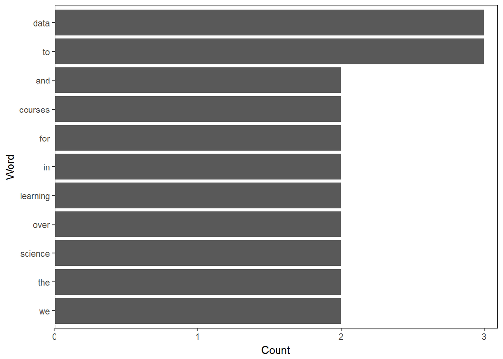

```r
# Find the 10 most frequent terms: term_count
term_count <- freq_terms(new_text, 4)

# Plot term_count
plot(term_count)
```

### Building our first corpus

Corpus is a collection of documents

```r
# Import text data
tweets <- read.csv("./data/coffee.csv", stringsAsFactors = FALSE)

# View the structure of tweets
str(tweets)
```

```
## 'data.frame':    1000 obs. of  6 variables:
##  $ screenName  : chr  "thejennagibson" "carolynicosia" "janeCkay" "AlexandriaOOTD" ...
##  $ retweetCount: int  0 1 0 0 2 0 0 0 1 2 ...
##  $ retweeted   : logi  FALSE FALSE FALSE FALSE FALSE FALSE ...
##  $ longitude   : logi  NA NA NA NA NA NA ...
##  $ latitude    : logi  NA NA NA NA NA NA ...
##  $ text        : chr  "@ayyytylerb that is so true drink lots of coffee" "RT @bryzy_brib: Senior March tmw morning at 7:25 A.M. in the SENIOR lot. Get up early, make yo coffee/breakfast, cus this will "| __truncated__ "If you believe in #gunsense tomorrow would be a very good day to have your cof…
```

```r
# Print out the number of rows in tweets
nrow(tweets)
```

```
## [1] 1000
```

```r
# Isolate text from tweets: coffee_tweets
coffee_tweets <- tweets$text
```

### Vcorpus from CSV

Recall that you’ve loaded your text data as a vector called coffee_tweets in the last exercise. Your next step is to convert this vector containing the text data to a corpus. As you’ve learned in the video, a corpus is a collection of documents, but it’s also important to know that in the tm domain, R recognizes it as a data type.

There are two kinds of the corpus data type, the permanent corpus, PCorpus, and the volatile corpus, VCorpus. In essence, the difference between the two has to do with how the collection of documents is stored in your computer. In this course, we will use the volatile corpus, which is held in your computer’s RAM rather than saved to disk, just to be more memory efficient.

To make a volatile corpus, R needs to interpret each element in our vector of text, coffee_tweets, as a document. And the tm package provides what are called Source functions to do just that! In this exercise, we’ll use a Source function called VectorSource() because our text data is contained in a vector. The output of this function is called a Source object. Give it a shot!

```r
# Load tm
library(tm)
# Make a vector source: coffee_source
coffee_source <- VectorSource(coffee_tweets)
```

Now that we’ve converted our vector to a Source object, we pass it to another tm function, VCorpus(), to create our volatile corpus. Pretty straightforward, right?

The VCorpus object is a nested list, or list of lists. At each index of the VCorpus object, there is a PlainTextDocument object, which is essentially a list that contains the actual text data (content), as well as some corresponding metadata (meta). It can help to visualize a VCorpus object to conceptualize the whole thing.

For example, to examine the contents of the second tweet in coffee_corpus, you’d subset twice. Once to specify the second PlainTextDocument corresponding to the second tweet and again to extract the first (or content) element of that PlainTextDocument:

```r
## coffee_source is already in your workspace

# Make a volatile corpus: coffee_corpus
coffee_corpus <- VCorpus(coffee_source)

# Print out coffee_corpus
coffee_corpus
```

```
## <<VCorpus>>
## Metadata:  corpus specific: 0, document level (indexed): 0
## Content:  documents: 1000
```

```r
# Print data on the 15th tweet in coffee_corpus
coffee_corpus[[15]]
```

```
## <<PlainTextDocument>>
## Metadata:  7
## Content:  chars: 111
```

```r
# Print the content of the 15th tweet in coffee_corpus
coffee_corpus[[15]]$content
```

```
## [1] "@HeatherWhaley I was about 2 joke it takes 2 hands to hold hot coffee...then I read headline! #Don'tDrinkNShoot"
```

```r
coffee_corpus[[15]][1]
```

```
## $content
## [1] "@HeatherWhaley I was about 2 joke it takes 2 hands to hold hot coffee...then I read headline! #Don'tDrinkNShoot"
```

### Vcorpus from data frame

Because another common text source is a data frame, there is a Source function called DataframeSource(). The DataframeSource() function treats the entire row as a complete document, so be careful you don’t pick up non-text data like customer IDs when sourcing a document this way.

```r
#example_text data frame
# num                             Author1               Author2
# 1   1        Text mining is a great time. R is a great language
# 2   2     Text analysis provides insights       R has many uses
# 3   3 qdap and tm are used in text mining     DataCamp is cool!
#
# # Print example_text to the console
# example_text
#
# # Create a DataframeSource on columns 2 and 3: df_source
# df_source <- DataframeSource(example_text[, 2:3])
#
# # Convert df_source to a corpus: df_corpus
# df_corpus <- VCorpus(df_source)
#
# # Examine df_corpus
# df_corpus
#
# # Create a VectorSource on column 3: vec_source
# vec_source <- VectorSource(example_text[, 3])
#
# # Convert vec_source to a corpus: vec_corpus
# vec_corpus <- VCorpus(vec_source)
#
# # Examine vec_corpus
# vec_corpus
```

### Cleaning and Preprocessing Text

#### Common cleaning functions from tm

Now that you know two ways to make a corpus, we can focus on cleaning, or preprocessing, the text. First, we’ll clean a small piece of text so you can see how it works. Then we will move on to actual corpora.

In bag of words text mining, cleaning helps aggregate terms. For example, it may make sense that the words “miner”, “mining” and “mine” should be considered one term. Specific preprocessing steps will vary based on the project. For example, the words used in tweets are vastly different than those used in legal documents, so the cleaning process can also be quite different.

Common preprocessing functions include:

tolower(): Make all characters lowercase removePunctuation(): Remove all punctuation marks removeNumbers(): Remove numbers stripWhitespace(): Remove excess whitespace Note that tolower() is part of base R, while the other three functions come from the tm package. Going forward, we’ll load the tm and qdap for you when they are needed. Every time we introduce a new package, we’ll have you load it the first time.

```r
# Create the object: text
text <- "<b>She</b> woke up at       6 A.M. It\'s so early!  She was only 10% awake and began drinking coffee in front of her computer."

# All lowercase
tolower(text)
```

```
## [1] "<b>she</b> woke up at       6 a.m. it's so early!  she was only 10% awake and began drinking coffee in front of her computer."
```

```r
# Remove punctuation
removePunctuation(text)
```

```
## [1] "bSheb woke up at       6 AM Its so early  She was only 10 awake and began drinking coffee in front of her computer"
```

```r
# Remove numbers
removeNumbers(text)
```

```
## [1] "<b>She</b> woke up at        A.M. It's so early!  She was only % awake and began drinking coffee in front of her computer."
```

```r
# Remove whitespace
stripWhitespace(text)
```

```
## [1] "<b>She</b> woke up at 6 A.M. It's so early! She was only 10% awake and began drinking coffee in front of her computer."
```

#### Cleaning with qdap

The qdap package offers other text cleaning functions. Each is useful in its own way and is particularly powerful when combined with the others.

bracketX(): Remove all text within brackets (e.g. “It’s (so) cool” becomes “It’s cool”) replace_number(): Replace numbers with their word equivalents (e.g. “2” becomes “two”) replace_abbreviation(): Replace abbreviations with their full text equivalents (e.g. “Sr” becomes “Senior”) replace_contraction(): Convert contractions back to their base words (e.g. “shouldn’t” becomes “should not”) replace_symbol() Replace common symbols with their word equivalents (e.g. “$” becomes “dollar”)

```r
library(qdap)
# Remove text within brackets
bracketX(text)
```

```
## [1] "She woke up at 6 A.M. It's so early! She was only 10% awake and began drinking coffee in front of her computer."
```

```r
# Replace numbers with words
replace_number(text)
```

```
## [1] "<b>She</b> woke up at six A.M. It's so early! She was only ten% awake and began drinking coffee in front of her computer."
```

```r
# Replace abbreviations
replace_abbreviation(text)
```

```
## [1] "<b>She</b> woke up at 6 AM It's so early! She was only 10% awake and began drinking coffee in front of her computer."
```

```r
# Replace contractions
replace_contraction(text)
```

```
## [1] "<b>She</b> woke up at 6 A.M. it is so early! She was only 10% awake and began drinking coffee in front of her computer."
```

```r
# Replace symbols with words
replace_symbol(text)
```

```
## [1] "<b>She</b> woke up at 6 A.M. It's so early! She was only 10 percent awake and began drinking coffee in front of her computer."
```

#### All about stop words

Often there are words that are frequent but provide little information. So you may want to remove these so-called stop words. Some common English stop words include “I”, “she’ll”, “the”, etc. In the tm package, there are 174 stop words on this common list.

In fact, when you are doing an analysis you will likely need to add to this list. In our coffee tweet example, all tweets contain “coffee”, so it’s important to pull out that word in addition to the common stop words. Leaving it in doesn’t add any insight and will cause it to be overemphasized in a frequency analysis.

Using the c() function allows you to add new words (separated by commas) to the stop words list. For example, the following would add “word1” and “word2” to the default list of English stop words:

all_stops <- c(“word1”, “word2”, stopwords(“en”)) Once you have a list of stop words that makes sense, you will use the removeWords() function on your text. removeWords() takes two arguments: the text object to which it’s being applied and the list of words to remove.

```r
## text is preloaded into your workspace

# List standard English stop words
stopwords("en")
```

```
##   [1] "i"          "me"         "my"         "myself"     "we"
##   [6] "our"        "ours"       "ourselves"  "you"        "your"
##  [11] "yours"      "yourself"   "yourselves" "he"         "him"
##  [16] "his"        "himself"    "she"        "her"        "hers"
##  [21] "herself"    "it"         "its"        "itself"     "they"
##  [26] "them"       "their"      "theirs"     "themselves" "what"
##  [31] "which"      "who"        "whom"       "this"       "that"
##  [36] "these"      "those"      "am"         "is"         "are"
##  [41] "was"        "were"       "be"         "been"       "being"
##  [46] "have"       "has"        "had"        "having"     "do"
##  [51] "does"       "did"        "doing"      "would"      "should"
##  [56] "could"      "ought"      "i'm"        "you're"     "he's"
##  [61] "she's"      "it's"       "we're"      "they're"    "i've"
##  [66] "you've"     "we've"      "they've"    "i'd"        "you'd"
##  [71] "he'd"       "she'd"      "we'd"       "they'd"     "i'll"
```

[output cut: 20 more lines]

```r
# Print text without standard stop words
removeWords(text, stopwords("en"))
```

```
## [1] "<b>She</b> woke         6 A.M. It's  early!  She   10% awake  began drinking coffee  front   computer."
```

```r
# Add "coffee" and "bean" to the list: new_stops
new_stops <- c("coffee", "bean", stopwords("en"))

# Remove stop words from text
removeWords(text, new_stops)
```

```
## [1] "<b>She</b> woke         6 A.M. It's  early!  She   10% awake  began drinking   front   computer."
```

### Intro to word stemming and stem completion

Still another useful preprocessing step involves word stemming and stem completion. The tm package provides the stemDocument() function to get to a word’s root. This function either takes in a character vector and returns a character vector, or takes in a PlainTextDocument and returns a PlainTextDocument.

For example,

stemDocument(c(“computational”, “computers”, “computation”)) returns “comput” “comput” “comput”. But because “comput” isn’t a real word, we want to re-complete the words so that “computational”, “computers”, and “computation” all refer to the same word, say “computer”, in our ongoing analysis.

We can easily do this with the stemCompletion() function, which takes in a character vector and an argument for the completion dictionary. The completion dictionary can be a character vector or a Corpus object. Either way, the completion dictionary for our example would need to contain the word “computer” for all the words to refer to it.

```r
# Create complicate
complicate <- c("complicated", "complication", "complicatedly")

# Perform word stemming: stem_doc
stem_doc <- stemDocument(complicate)

# Create the completion dictionary: comp_dict
comp_dict <- c("complicate")

# Perform stem completion: complete_text
complete_text <- stemCompletion(stem_doc, comp_dict)

# Print complete_text
complete_text
```

```
##      complic      complic      complic
## "complicate" "complicate" "complicate"
```

### Word stemming and stem completion on a sentence

Let’s consider the following sentence as our document for this exercise:

“In a complicated haste, Tom rushed to fix a new complication, too complicatedly.” This sentence contains the same three forms of the word “complicate” that we saw in the previous exercise. The difference here is that even if you called stemDocument() on this sentence, it would return the sentence without stemming any words. Take a moment and try it out in the console. Be sure to include the punctuation marks.

This happens because stemDocument() treats the whole sentence as one word. In other words, our document is a character vector of length 1, instead of length n, where n is the number of words in the document. To solve this problem, we first remove the punctation marks with the removePunctuation() function you learned a few exercises back. We then strsplit() this character vector of length 1 to length n, unlist(), then proceed to stem and re-complete.

Don’t worry if that was confusing. Let’s go through the process step by step!

```r
text_data <- "In a complicated haste, Tom rushed to fix a new complication, too complicatedly."
comp_dict <- c("In","a","complicate","haste","Tom","rush","to","fix","new","too")

# Remove punctuation: rm_punc
rm_punc <- removePunctuation(text_data)

# Create character vector: n_char_vec
n_char_vec <- unlist(strsplit(rm_punc, split = ' '))

# Perform word stemming: stem_doc
stem_doc <- stemDocument(n_char_vec)

# Print stem_doc
stem_doc
```

```
##  [1] "In"      "a"       "complic" "hast"    "Tom"     "rush"    "to"
##  [8] "fix"     "a"       "new"     "complic" "too"     "complic"
```

```r
# Re-complete stemmed document: complete_doc
complete_doc <- stemCompletion(stem_doc, comp_dict)

# Print complete_doc
complete_doc
```

```
##           In            a      complic         hast          Tom
##         "In"          "a" "complicate"      "haste"        "Tom"
##         rush           to          fix            a          new
##       "rush"         "to"        "fix"          "a"        "new"
##      complic          too      complic
## "complicate"        "too" "complicate"
```

### Apply preprocessing steps to a corpus

The tm package provides a special function tm_map() to apply cleaning functions to a corpus. Mapping these functions to an entire corpus makes scaling the cleaning steps very easy.

To save time (and lines of code) it’s a good idea to use a custom function like the one displayed in the editor, since you may be applying the same functions over multiple corpora. You can probably guess what the clean_corpus() function does. It takes one argument, corpus, and applies a series of cleaning functions to it in order, then returns the final result.

Notice how the tm package functions do not need content_transformer(), but base R and qdap functions do.

Be sure to test your function’s results. If you want to draw out currency amounts, then removeNumbers() shouldn’t be used! Plus, the order of cleaning steps makes a difference. For example, if you removeNumbers() and then replace_number(), the second function won’t find anything to change! Check, check, and re-check!

```r
library(tm)
# Alter the function code to match the instructions
clean_corpus <- function(corpus){
  corpus <- tm_map(corpus, content_transformer(replace_abbreviation))
  corpus <- tm_map(corpus, removePunctuation)
  corpus <- tm_map(corpus, removeNumbers)
  corpus <- tm_map(corpus, removeWords, c(stopwords("en"), "coffee"))
  corpus <- tm_map(corpus, content_transformer(tolower))
  return(corpus)
}
tweet_corp <- coffee_corpus

# Alter the function code to match the instructions
clean_corpus <- function(corpus){
  corpus <- tm_map(corpus, stripWhitespace)
  corpus <- tm_map(corpus, removePunctuation)
  corpus <- tm_map(corpus, content_transformer(tolower))
  corpus <- tm_map(corpus, removeWords, c(stopwords("en"), "coffee", "mug"))
  return(corpus)
}

# Apply your customized function to the tweet_corp: clean_corp
clean_corp <- clean_corpus(tweet_corp)

# Print out a cleaned up tweet
clean_corp[[227]][1]
```

```
## $content
## [1] "also dogs arent smart enough  dip  donut      eat  part thats  dipped ladyandthetramp"
```

```r
# Print out the same tweet in original form
tweet_corp[[227]][1]
```

```
## $content
## [1] "Also, dogs aren't smart enough to dip the donut in the coffee and then eat the part that's been dipped. #ladyandthetramp"
```

### TDM v DTM

TDM - Term Document Matrix DTM - Document Term Matrix

word frequency matrices can be derived from a TDM

#### Make a document-term matrix

Hopefully you are not too tired after all this basic text mining work! Just in case, let’s revisit the coffee tweets to build a document-term matrix.

Beginning with the coffee.csv file, we have used common transformations to produce a clean corpus called clean_corp.

The document-term matrix is used when you want to have each document represented as a row. This can be useful if you are comparing authors within rows, or the data is arranged chronologically and you want to preserve the time series.

```r
# Create the dtm from the corpus: coffee_dtm
library(qdap)
library(tm)
coffee_dtm <- DocumentTermMatrix(clean_corp)

# Print out coffee_dtm data
coffee_dtm
```

```
## <<DocumentTermMatrix (documents: 1000, terms: 3075)>>
## Non-/sparse entries: 7372/3067628
## Sparsity           : 100%
## Maximal term length: 27
## Weighting          : term frequency (tf)
```

```r
# Convert coffee_dtm to a matrix: coffee_m
coffee_m <- as.matrix(coffee_dtm)

# Print the dimensions of coffee_m
dim(coffee_m)
```

```
## [1] 1000 3075
```

```r
# Review a portion of the matrix
coffee_m[148:150, 2587:2590]
```

```
##      Terms
## Docs  stampedeblue stand star starbucks
##   148            0     0    0         0
##   149            0     0    0         0
##   150            0     0    0         0
```

### Make a term-document matrix

You’re almost done with the not-so-exciting foundational work before we get to some fun visualizations and analyses based on the concepts you’ve learned so far!

In this exercise, you are performing a similar process but taking the transpose of the document-term matrix. In this case, the term-document matrix has terms in the first column and documents across the top as individual column names.

The TDM is often the matrix used for language analysis. This is because you likely have more terms than authors or documents and life is generally easier when you have more rows than columns. An easy way to start analyzing the information is to change the matrix into a simple matrix using as.matrix() on the TDM.

```r
# Create a TDM from clean_corp: coffee_tdm
coffee_tdm <- TermDocumentMatrix(clean_corp)

# Print coffee_tdm data
coffee_tdm
```

```
## <<TermDocumentMatrix (terms: 3075, documents: 1000)>>
## Non-/sparse entries: 7372/3067628
## Sparsity           : 100%
## Maximal term length: 27
## Weighting          : term frequency (tf)
```

```r
# Convert coffee_tdm to a matrix: coffee_m
coffee_m <- as.matrix(coffee_tdm)

# Print the dimensions of the matrix
dim(coffee_m)
```

```
## [1] 3075 1000
```

```r
# Review a portion of the matrix
coffee_m[2587:2590, 148:150]
```

```
##               Docs
## Terms          148 149 150
##   stampedeblue   0   0   0
##   stand          0   0   0
##   star           0   0   0
##   starbucks      0   0   0
```

## Making Visuals

Now that you know how to make a term-document matrix, as well as its transpose, the document-term matrix, we will use it as the basis for some analysis. In order to analyze it we need to change it to a simple matrix like we did in chapter 1 using as.matrix.

Calling rowSums() on your newly made matrix aggregates all the terms used in a passage. Once you have the rowSums(), you can sort() them with decreasing = TRUE, so you can focus on the most common terms.

Lastly, you can make a barplot() of the top 5 terms of term_frequency with the following code.

barplot(term_frequency[1:5], col = “#C0DE25”) Of course, you could take our ggplot2 course to learn how to customize the plot even more… :)

```r
## coffee_tdm is still loaded in your workspace

# Create a matrix: coffee_m
coffee_m <- as.matrix(coffee_tdm)


# Calculate the rowSums: term_frequency
term_frequency <- rowSums(coffee_m)

# Sort term_frequency in descending order
term_frequency <- sort(term_frequency, decreasing = TRUE)

# View the top 10 most common words
term_frequency[1:10]
```

```
##     like      cup     shop     just      get  morning     want drinking
##      110      103       68       66       62       57       49       47
##      can    looks
##       45       44
```

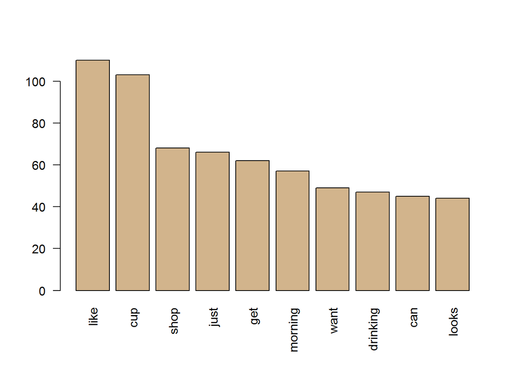

```r
# Plot a barchart of the 10 most common words
barplot(term_frequency[1:10], col = "tan", las = 2)
```

### Frequent terms with qdap

If you are OK giving up some control over the exact preproccessing steps, then a fast way to get frequent terms is with freq_terms() from qdap.

The function accepts a text variable, which in our case is the tweets$text vector. You can specify the top number of terms to show with the top argument, a vector of stop words to remove with the stopwords argument, and the minimum character length of a word to be included with the at.least argument. qdap has its own list of stop words that differ from those in tm. Our exercise will show you how to use either and compare their results.

Making a basic plot of the results is easy. Just call plot() on the freq_terms() object.

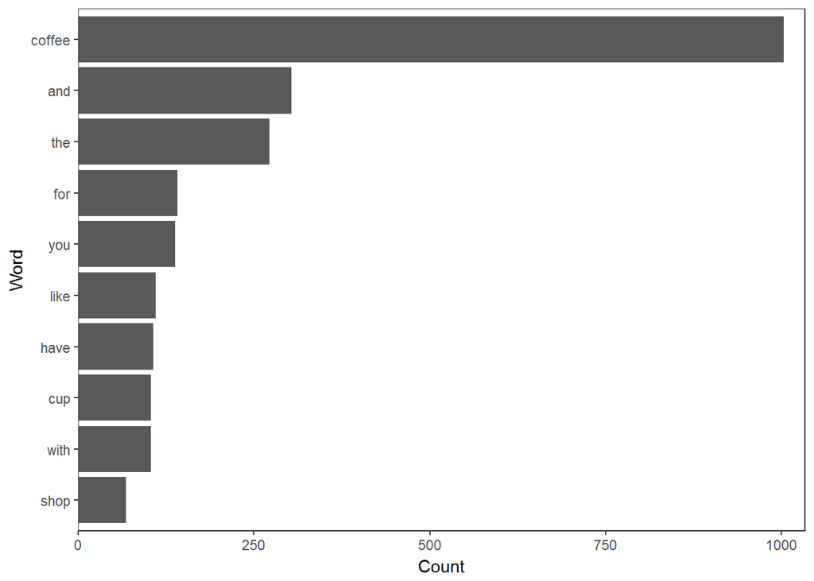

```r
# Create frequency
library(qdap)
frequency <- freq_terms(tweets$text, top = 10, at.least = 3, stopwords = "Top200Words" )

# Make a frequency barchart
plot(frequency)
```

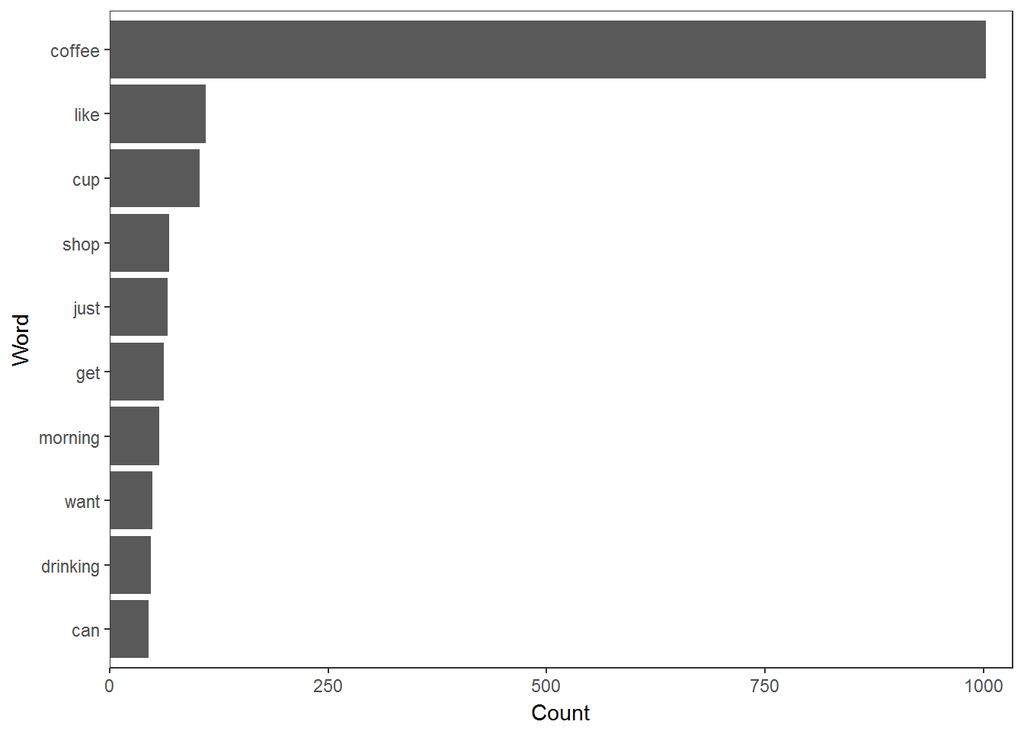

```r
# Create frequency2
frequency2 <- freq_terms(tweets$text, top = 10, at.least = 3, stopwords = tm::stopwords("en"))

# Make a frequency2 barchart
plot(frequency2)
```

### A simple word cloud

At this point you have had too much coffee. Plus, seeing the top words such as “shop”, “morning”, and “drinking” among others just isn’t all that insightful.

In celebration of making it this far, let’s try our hand on another batch of 1000 tweets. For now, you won’t know what they have in common, but let’s see if you can figure it out using a word cloud. The tweets’ term-document matrix, matrix, and frequency values are preloaded in your workspace.

A word cloud is a visualization of terms. In a word cloud, size is often scaled to frequency and in some cases the colors may indicate another measurement. For now, we’re keeping it simple: size is related to individual word frequency and we are just selecting a single color.

As you saw in the video, the wordcloud() function works like this:

wordcloud(words, frequencies, max.words = 500, colors = “blue”) Text mining analyses often include simple word clouds. In fact, they are probably over used, but can still be useful for quickly understanding a body of text!

```r
remove(list= ls())
term_frequency0 <- read.csv("./data/text_frequency.csv", header = FALSE, stringsAsFactors = FALSE)


term_frequency_names <- (term_frequency0$V1)

term_frequency_nums <- as.numeric(c(term_frequency0$V2))

names(term_frequency_nums) <- term_frequency_names

term_frequency <- term_frequency_nums

str(term_frequency)
```

```
##  Named num [1:2983] 824 104 83 76 75 63 52 47 43 35 ...
##  - attr(*, "names")= chr [1:2983] "chardonnay" "marvin" "wine" "gaye" ...
```

```r
## term_frequency is loaded into your workspace

# Load wordcloud package
library(wordcloud)

# Print the first 10 entries in term_frequency
term_frequency[1:10]
```

```
## chardonnay     marvin       wine       gaye       just      glass
##        824        104         83         76         75         63
##       like     bottle        lol     little
##         52         47         43         35
```

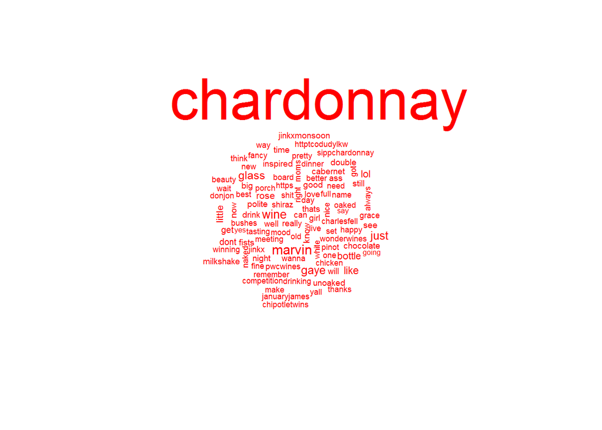

```r
# Create word_freqs
word_freqs <- data.frame(term = names(term_frequency), num = term_frequency)

# Create a wordcloud for the values in word_freqs
wordcloud(word_freqs$term, word_freqs$num, max.words = 100, colors = "red")
```

### Stop words and word clouds

Now that you are in the text mining mindset, sitting down for a nice glass of chardonnay, we need to dig deeper. In the last word cloud, “chardonnay” dominated the visual. It was so dominant that you couldn’t draw out any other interesting insights.

Let’s change the stop words to include “chardonnay” to see what other words are common, yet were originally drowned out.

The previous word cloud used the clean_corpus() function below: clean_corpus <- function(corpus){ corpus <- tm_map(corpus, removePunctuation) corpus <- tm_map(corpus, stripWhitespace) corpus <- tm_map(corpus, removeNumbers) corpus <- tm_map(corpus, content_transformer(tolower)) corpus <- tm_map(corpus, removeWords, c(stopwords(“en”), “amp”)) return(corpus) }

```r
chardonnay_rds <- readRDS("./data/c2_chardonnay_m.rds")

chardonnay_text <- attributes(chardonnay_rds)$dimnames$Terms


chardonnay_source <- VectorSource(chardonnay_text)

chardonnay_corp <- VCorpus(chardonnay_source)

# Add new stop words to clean_corpus()

clean_corpus <- function(corpus){
  corpus <- tm_map(corpus, removePunctuation)
  corpus <- tm_map(corpus, stripWhitespace)
  corpus <- tm_map(corpus, removeNumbers)
  corpus <- tm_map(corpus, content_transformer(tolower))
  corpus <- tm_map(corpus, removeWords,
                   c(stopwords("en"), "amp", "chardonnay", "wine", "glass"))
  return(corpus)
}

# Create clean_chardonnay
clean_chardonnay <- clean_corpus(chardonnay_corp)

# Create chardonnay_tdm
chardonnay_tdm <- TermDocumentMatrix(clean_chardonnay)

# Create chardonnay_m
chardonnay_m <- as.matrix(chardonnay_tdm)

# Create chardonnay_words
chardonnay_words <- rowSums(chardonnay_m)
#See next section for real chardonnay_words - had some issues with extracting from the corpus but this works
```

### Plot the better word cloud

Now that you’ve added new stop words to the clean_corpus() function, let’s take a look at the improved word cloud!

Your results from the previous exercise are preloaded into your workspace. Let’s take a look at these new results.

```r
# Sort the chardonnay_words in descending order
chardonnay_words0 <- read.csv("./data/chardonnay_clean.csv", header = FALSE, stringsAsFactors = FALSE)
chardonnay_words_names <- (chardonnay_words0$V1)

chardonnay_words_nums <- as.numeric(c(chardonnay_words0$V2))

names(chardonnay_words_nums) <- chardonnay_words_names

chardonnay_words <- chardonnay_words_nums

chardonnay_words <- sort(chardonnay_words, decreasing = TRUE)

# Print the 6 most frequent chardonnay terms
chardonnay_words[1:6]
```

[output not shown]

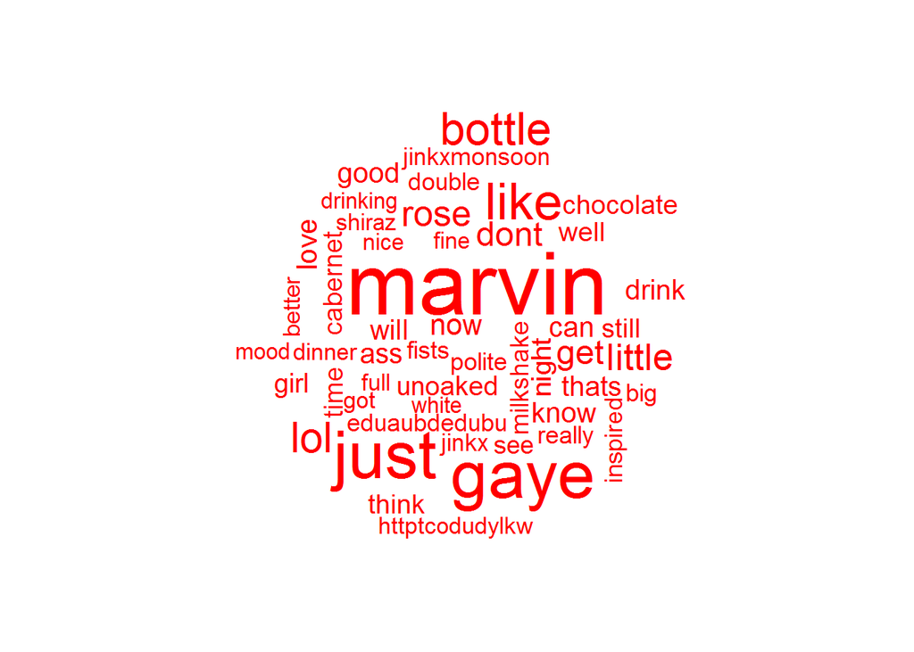

```r
# Create chardonnay_freqs
chardonnay_freqs <- data.frame(term = names(chardonnay_words), num = chardonnay_words)

# Create a wordcloud for the values in word_freqs
wordcloud(chardonnay_freqs$term, chardonnay_freqs$num, max.words = 50, colors = "red")
```

### Improve word cloud colors

So far, you have specified only a single hexidecimal color to make your word clouds. You can easily improve the appearance of a word cloud. Instead of the #AD1DA5 in the code below, you can specify a vector of colors to make certain words stand out or to fit an existing color scheme. wordcloud(chardonnay_freqs$term, chardonnay_freqs$num, max.words = 100, colors = “#AD1DA5”)

To change the colors argument of the wordcloud() function, you can use a vector of named colors like c(“chartreuse”, “cornflowerblue”, “darkorange”). The function colors() will list all 657 named colors. You can also use this PDF as a reference.

```r
# Print the list of colors
colors()
```

```
##   [1] "white"                "aliceblue"            "antiquewhite"
##   [4] "antiquewhite1"        "antiquewhite2"        "antiquewhite3"
##   [7] "antiquewhite4"        "aquamarine"           "aquamarine1"
##  [10] "aquamarine2"          "aquamarine3"          "aquamarine4"
##  [13] "azure"                "azure1"               "azure2"
##  [16] "azure3"               "azure4"               "beige"
##  [19] "bisque"               "bisque1"              "bisque2"
##  [22] "bisque3"              "bisque4"              "black"
##  [25] "blanchedalmond"       "blue"                 "blue1"
##  [28] "blue2"                "blue3"                "blue4"
##  [31] "blueviolet"           "brown"                "brown1"
##  [34] "brown2"               "brown3"               "brown4"
##  [37] "burlywood"            "burlywood1"           "burlywood2"
##  [40] "burlywood3"           "burlywood4"           "cadetblue"
##  [43] "cadetblue1"           "cadetblue2"           "cadetblue3"
```

[output cut: 204 more lines]

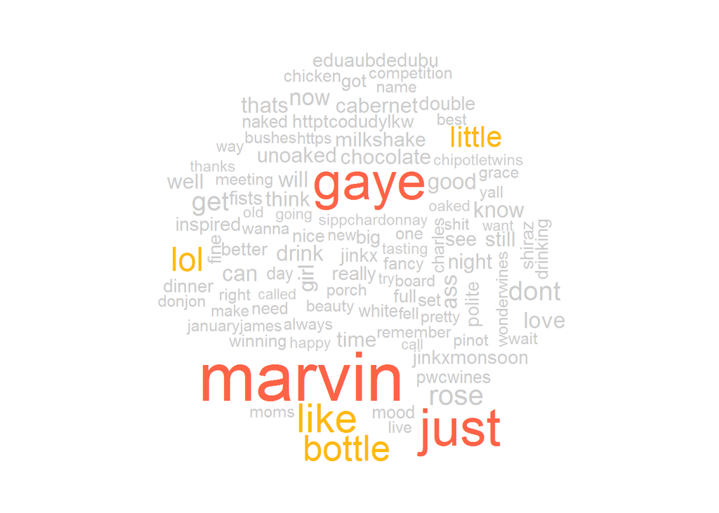

```r
# Print the wordcloud with the specified colors
wordcloud(chardonnay_freqs$term,
          chardonnay_freqs$num,
          max.words = 100,
          colors = c("grey80", "darkgoldenrod1", "tomato"))
```

### Use prebuilt color palettes

In celebration of your text mining skills, you may have had too many glasses of chardonnay while listening to Marvin Gaye. If that’s the case and you find yourself unable to pick good looking colors on your own, you can use the RColorBrewer package to help. RColorBrewer color schemes are organized into three categories: • Sequential: Colors ascend from light to dark in sequence • Qualitative: Colors are chosen for their pleasing qualities together • Diverging: Colors have two distinct color spectra with lighter colors in between

To change the colors parameter of the wordcloud() function you can use a select a palette from RColorBrewer such as “Greens”. The function display.brewer.all() will list all predefined color palettes. More information on ColorBrewer (the framework behind RColorBrewer) is available on its website.

The function brewer.pal() allows you to select colors from a palette. Specify the number of distinct colors needed (e.g. 8) and the predefined palette to select from (e.g. “Greens”). Often in word clouds, very faint colors are washed out so it may make sense to remove the first couple from a brewer.pal() selection, leaving only the darkest.

Here’s an example: green_pal <- brewer.pal(8, “Greens”) green_pal <- green_pal[-(1:2)]

Then just add that object to the wordcloud() function. wordcloud(chardonnay_freqs$term, chardonnay_freqs$num, max.words = 100, colors = green_pal)

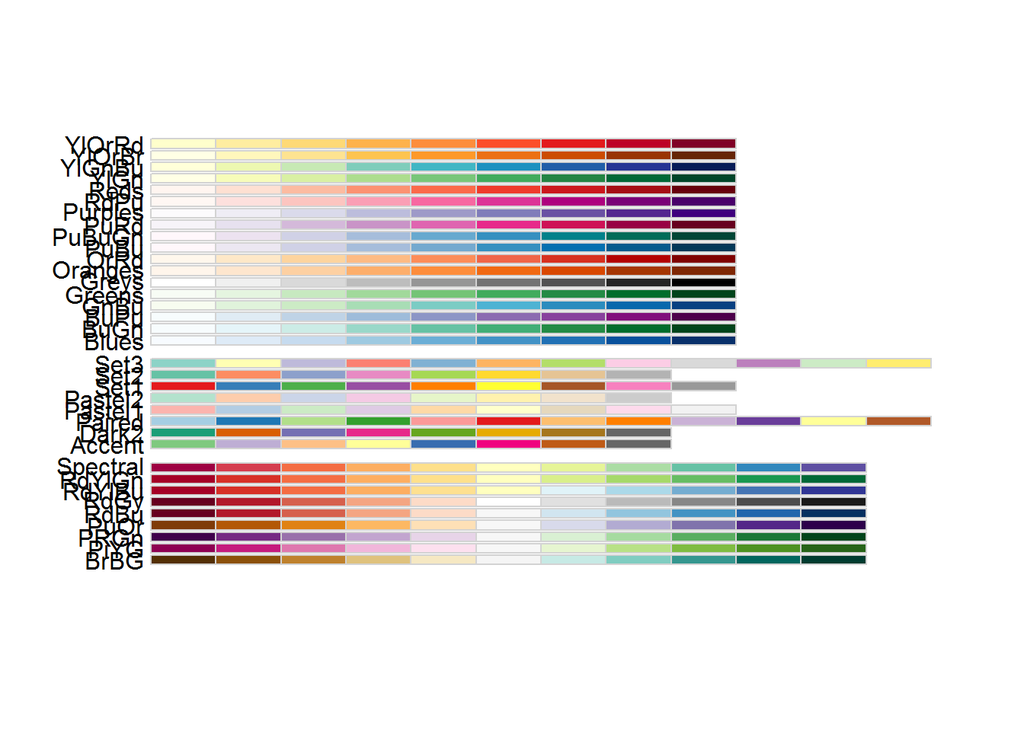

```r
# List the available colors
display.brewer.all()
```

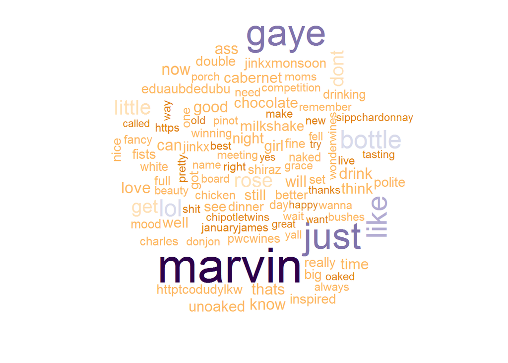

```r
# Create purple_orange
purple_orange <- brewer.pal(10, "PuOr")

# Drop 2 faintest colors
purple_orange <- purple_orange[-(1:2)]

# Create a wordcloud with purple_orange palette
wordcloud(chardonnay_freqs$term,
          chardonnay_freqs$num,
          max.words = 100,
          colors = purple_orange)
```

### Find Common Words

Say you want to visualize common words across multiple documents. You can do this with commonality.cloud().

Each of our coffee and chardonnay corpora is composed of many individual tweets. To treat the coffee tweets as a single document and likewise for chardonnay, you paste() together all the tweets in each corpus along with the parameter collapse = " “. This collapses all tweets (separated by a space) into a single vector. Then you can create a vector containing the two collapsed documents.

```r
chardonnay_tweets <- read.csv("./data/chardonnay_tweets.csv", stringsAsFactors = FALSE)
coffee_tweets <- read.csv("./data/coffee_tweets.csv", stringsAsFactors = FALSE)

# Create all_coffee
all_coffee <- paste(coffee_tweets$text, collapse = " ")
#all_coffee <- paste(coffee_tweets, collapse = " ")
str(all_coffee)
```

```
##  chr "@ayyytylerb that is so true drink lots of coffee RT @bryzy_brib: Senior March tmw morning at 7:25 A.M. in the SENIOR lot. Get u"| __truncated__
```

```r
# Create all_chardonnay
all_chardonnay <- paste(chardonnay_tweets$text, collapse = " ")
#all_chardonnay <- paste(chardonnay_tweets, collapse = " ")

# Create all_tweets
all_tweets <- c(all_coffee, all_chardonnay)

# Convert to a vector source
all_tweets <- VectorSource(all_tweets)

# Create all_corpus
all_corpus <- VCorpus(all_tweets)
```

### Visiualize Common Words

Now that you have a corpus filled with words used in both the chardonnay and coffee tweets files, you can clean the corpus, convert it into a TermDocumentMatrix, and then a matrix to prepare it for a commonality.cloud()

The commonality.cloud() function accepts this matrix object, plus additional arguments like max.words and colors to further customize the plot.

commonality.cloud(tdm_matrix, max.words = 100, colors = “springgreen”)

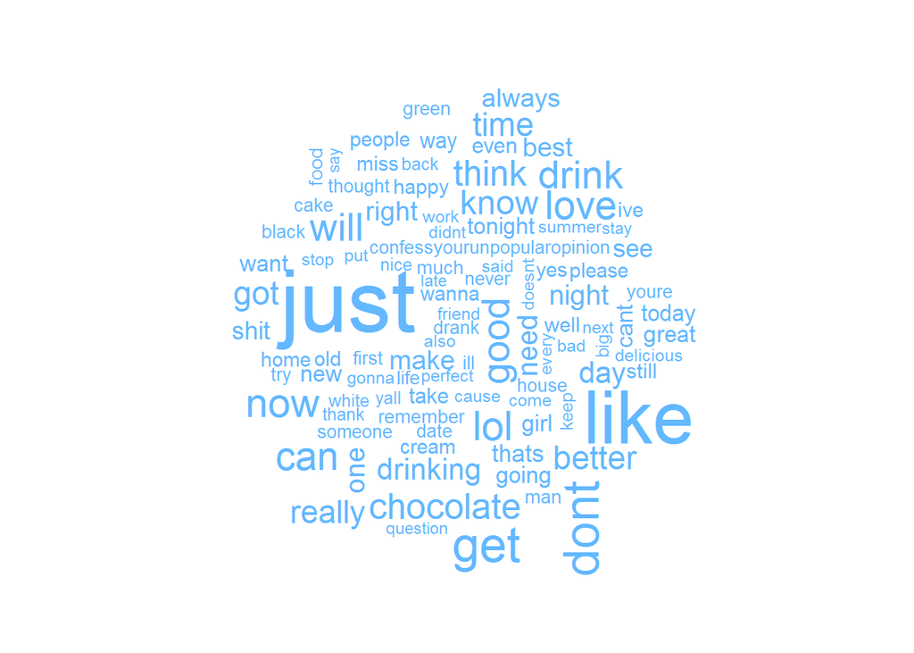

```r
#Create modified clean_corpus function
clean_corpus <- function(corpus){
  corpus <- tm_map(corpus, removePunctuation)
  corpus <- tm_map(corpus, stripWhitespace)
  corpus <- tm_map(corpus, removeNumbers)
  corpus <- tm_map(corpus, content_transformer(tolower))
  corpus <- tm_map(corpus, removeWords, c(stopwords("en"), "amp", "glass", "chardonnay", "coffee"))
  return(corpus)
}

# Clean the corpus
all_clean <- clean_corpus(all_corpus)

# Create all_tdm
all_tdm <- TermDocumentMatrix(all_clean)

# Create all_m
all_m <- as.matrix(all_tdm)

# Print a commonality cloud
commonality.cloud(all_m, max.words = 100, colors = "steelblue1")
```

### Visualize dissimilar words

Say you want to visualize the words not in common. To do this, you can also use comparison.cloud() and the steps are quite similar with one main difference.

Like when you were searching for words in common, you start by unifying the tweets into distinct corpora and combining them into their own VCorpus() object. Next apply a clean_corpus() function and organize it into a TermDocumentMatrix.

To keep track of what words belong to coffee versus chardonnay, you can set the column names of the TDM like this:

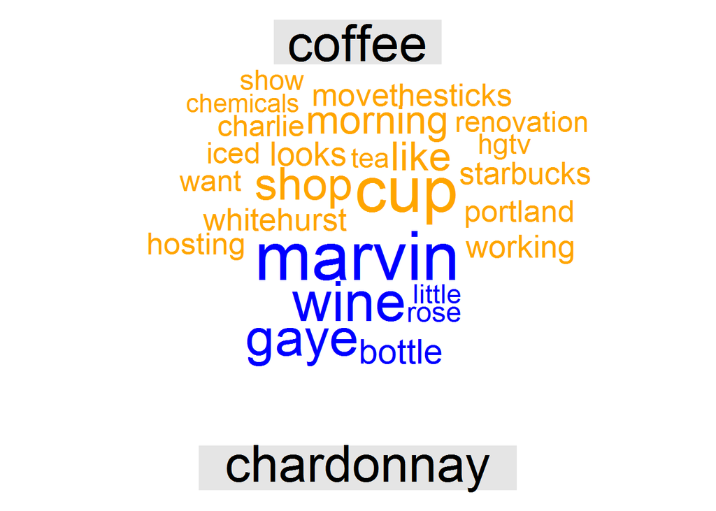

```r
# Clean the corpus
all_clean <- clean_corpus(all_corpus)

# Create all_tdm
all_tdm <- TermDocumentMatrix(all_clean)

# Give the columns distinct names
colnames(all_tdm) <- c("coffee", "chardonnay")

# Create all_m
all_m <- as.matrix(all_tdm)

# Create comparison cloud
comparison.cloud(all_m, colors = c("orange", "blue"), max.words = 25)
```

### Polarized tag cloud

A commonality.cloud() may be misleading since words could be represented disproportionately in one corpus or the other, even if they are shared. In the commonality cloud, they would show up without telling you which one of the corpora has more term occurrences. To solve this problem, we can create a pyramid.plot() from the plotrix package.

same_words <- subset(all_tdm_m, all_tdm_m[, 1] > 0 & all_tdm_m[, 2] > 0) Once you have the terms that are common to both corpora, you can create a new column in same_words that contains the absolute difference between how often each term is used in each corpus.

To identify the words that differ the most between documents, we must order() the rows of same_words by the absolute difference column with decreasing = TRUE like this:

same_words <- same_words[order(same_words[, 3], decreasing = TRUE), ] Now that same_words is ordered by the absolute difference, let’s create a small data.frame() of the 20 top terms so we can pass that along to pyramid.plot():

top_words <- data.frame( x = same_words[1:20, 1], y = same_words[1:20, 2], labels = rownames(same_words[1:20, ]) ) Note that top_words contains columns x and y for the frequency of the top words for each of the documents, and a third column, labels, that contains the words themselves.

Finally, you can create your pyramid.plot() and get a better feel for how the word usages differ by topic!

pyramid.plot(top_words$x, top_words$y, labels = top_words$labels, gap = 8, top.labels = c(“Chardonnay”, “Words”, “Coffee”), main = “Words in Common”, laxlab = NULL, raxlab = NULL, unit = NULL)

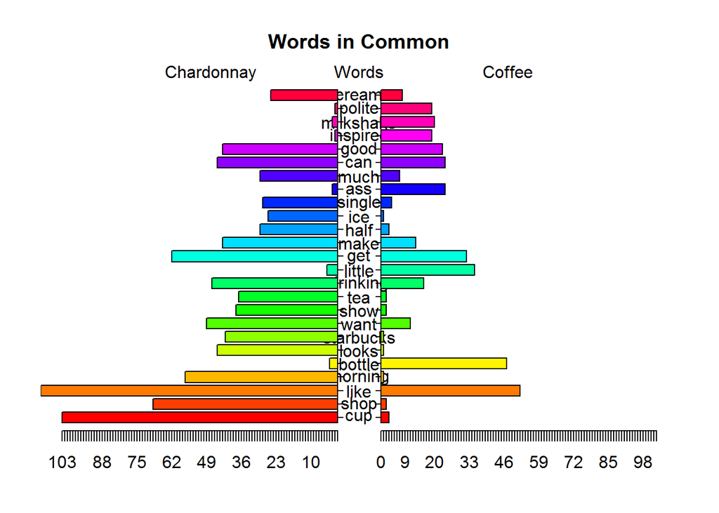

```
## [1] 5.1 4.1 4.1 2.1
```

```r
library(plotrix)
all_tdm_m <- as.matrix(all_tdm)

# Create common_words
common_words <- subset(all_tdm_m, all_tdm_m[, 1] > 0 & all_tdm_m[, 2] > 0)

# Create difference
difference <- abs(common_words[, 1] - common_words[, 2])

# Combine common_words and difference
common_words <- cbind(common_words, difference)

# Order the data frame from most differences to least
common_words <- common_words[order(common_words[, 3], decreasing = TRUE), ]

# Create top25_df
top25_df <- data.frame(x = common_words[1:25, 1],
                       y = common_words[1:25, 2],
                       labels = rownames(common_words[1:25, ]))

# Create the pyramid plot
pyramid.plot(top25_df$x, top25_df$y,
labels = top25_df$labels,
gap = 8,
top.labels = c("Chardonnay", "Words", "Coffee"),
main = "Words in Common",
laxlab = NULL,
raxlab = NULL,
unit = NULL)
```

### Visualize word networks

Another way to view word connections is to treat them as a network, similar to a social network. Word networks show term association and cohesion. A word of caution: these visuals can become very dense and hard to interpret visually.

In a network graph, the circles are called nodes and represent individual terms, while the lines connecting the circles are called edges and represent the connections between the terms.

For the over-caffeinated text miner, qdap provides a shorcut for making word networks. The word_network_plot() and word_associate() functions both make word networks easy!

The sample code constructs a word network for words associated with “Marvin”.

```r
# Word association
word_associate(chardonnay_tweets$text, match.string = c("marvin"),
               stopwords = c(Top200Words, "chardonnay", "amp"),
               network.plot = TRUE, cloud.colors = c("gray85", "darkred"))
```

```
##     row group unit text
## 1    14   all   14 This was all inspired by a little Marvin Gaye and Chardonnay...
## 2    16   all   16 @LilLakers JUST TO SET THE MOOD GIRL I BROUGHT SOME MARVIN GAYE AND CHARDONNAY SO JUST LET THE SONG PLAAAY
## 3    17   all   17 RT @_barneywynne_: Just to set the mood girl i brought some marvin gaye and chardonnay
## 4    18   all   18 @TylerHickok was it inspired by a little Marvin gaye abs chardonnay?
## 5    19   all   19 Just to set the mood girl i brought some marvin gaye and chardonnay
## 6    23   all   23 Marvin Gaye and Chardonnay
## 7    24   all   24 I brought some Marvin Gaye and Chardonnay.
## 8    26   all   26 RT @NowOnRadio1Xtra: Marvin &amp; Chardonnay - by Big Sean #bbc #radio1xtra
## 9    27   all   27 Marvin &amp; Chardonnay - by Big Sean #bbc #radio1xtra
## 10   48   all   48 Marvin Gaye and Chardonnay
## 11   67   all   67 Just to set the mood, girl i brought some marvin gaye and Chardonnay
## 12  101   all  101 Marvin gay and Chardonnay
## 13  126   all  126 This was all inspired by a little Marvin Gaye and Chardonnay
## 14  143   all  143 RT @Leinyy_Nicole: and this was all inspired by a little Marvin Gaye and Chardonnay..
```

[output cut: 89 more lines]

```
##
## Match Terms
## ===========
```

```
##
## List 1:
## marvin, 'marvin
```

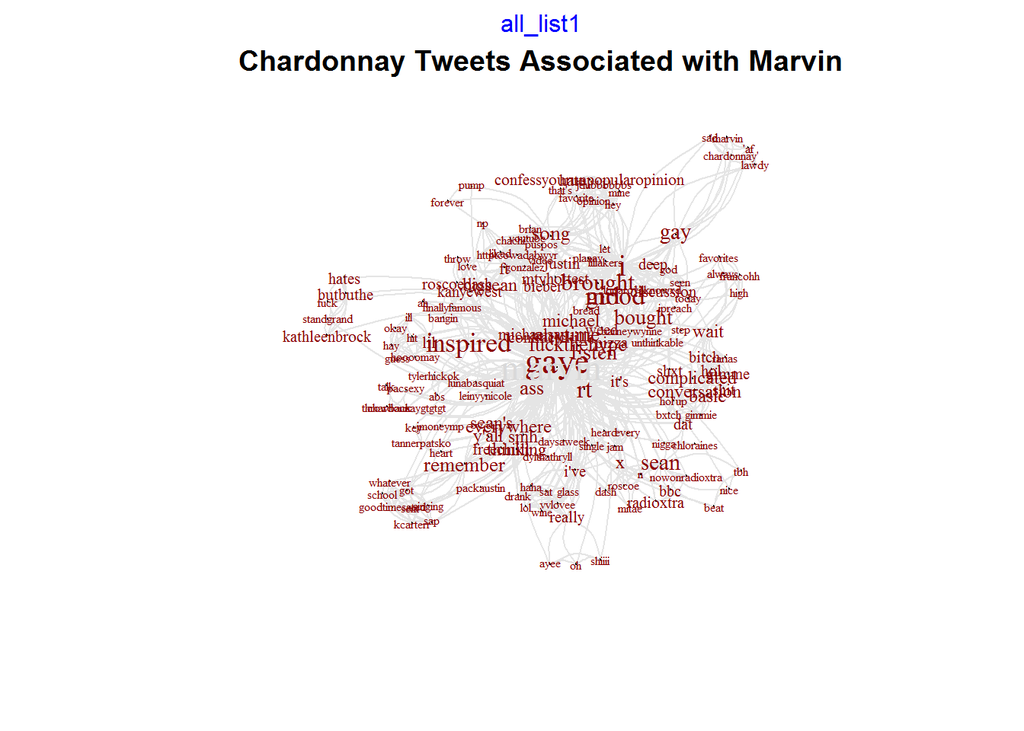

```r
# Add title
title(main = "Chardonnay Tweets Associated with Marvin")
```

```r
# Word association
word_associate(coffee_tweets$text, match.string = c("barista"),
               stopwords = c(Top200Words, "coffee", "amp"),
               network.plot = TRUE, cloud.colors = c("gray85", "darkred"))
```

```
##   row group unit text
## 1 544   all  544 RT @Barista_kyo: #coffee #latte #soylatte #thinkcoffee # # # # @ think coffee http://t.co/Hmy9RPRWTZ
## 2 569   all  569 RT @ReversoSmith: What a beautiful mess! #portafilter #coffee #espresso #coffeemachine #barista #baristalife? http://t.co/ZODcTfP22Z
## 3 658   all  658 The moment you realize your Starbucks barista gave you a regular iced Coffee when u asked 4 decaf. Shitty. Late night not planned.
## 4 931   all  931 Barista made my coffee wrong and still gave me both anyway #Starbucks #coffee #caffeine #upallnight http://t.co/iKCNwO8F6t
## 5 951   all  951 RT @FrankIero: hahaha @jamiasan :*gives Barista our Starbucks order* Barista: coffee? @jamiasan : yes, isn't this is a coffee store?
```

```
##
## Match Terms
## ===========
```

```
##
## List 1:
## baristakyo, barista, baristalife
```

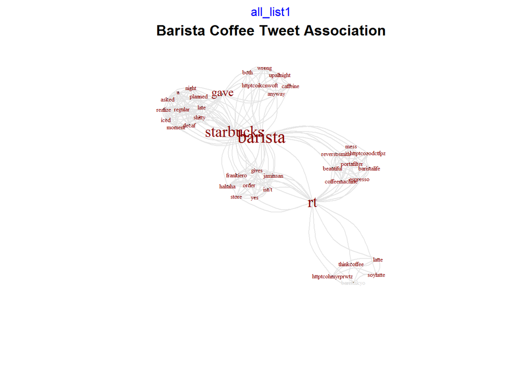

```r
# Add title
title(main = "Barista Coffee Tweet Association")
```

### Teaser: simple word clustering

In the next chapter, we cover some miscellaneous (yet very important) text mining subjects including:

TDM/DTM weighting Dealing with TDM/DTM sparsity Capturing metadata Simple word clustering for topics Analysis on more than one word For now, let’s simply create a new visual called a dendrogram from our coffee_tweets. The next chapter will explain it in detail.

```r
##data camp does not provide the 'hc' object - so this code is just for looking :)
# Plot a dendrogram
#plot(hc)
#hc
```

### Distance matrix and dendrogram

A simple way to do word cluster analysis is with a dendrogram on your term-document matrix. Once you have a TDM, you can call dist() to compute the differences between each row of the matrix.

Next, you call hclust() to perform cluster analysis on the dissimilarities of the distance matrix. Lastly, you can visualize the word frequency distances using a dendrogram and plot(). Often in text mining, you can tease out some interesting insights or word clusters based on a dendrogram.

Consider the table of annual rainfall that you saw in the last video. Cleveland and Portland have the same amount of rainfall, so their distance is 0. You might expect the two cities to be a cluster and for New Orleans to be on its own since it gets vastly more rain.

```
   city rainfall
```

Cleveland 39.14 Portland 39.14 Boston 43.77 New Orleans 62.45

```r
city <- c("Cleveland", "Portland", "Boston", "New Orleans")
rainfall <- c(39.14, 39.14, 43.77, 62.45)
rain <- as.data.frame(cbind(city = city, rainfall = rainfall))
library(graphics)
str(rain)
```

```
## 'data.frame':    4 obs. of  2 variables:
##  $ city    : Factor w/ 4 levels "Boston","Cleveland",..: 2 4 1 3
##  $ rainfall: Factor w/ 3 levels "39.14","43.77",..: 1 1 2 3
```

```r
# Create dist_rain
dist_rain <- dist(rain[, 2])

# View the distance matrix
dist_rain
```

```
##       1     2     3
## 2  0.00
## 3  4.63  4.63
## 4 23.31 23.31 18.68
```

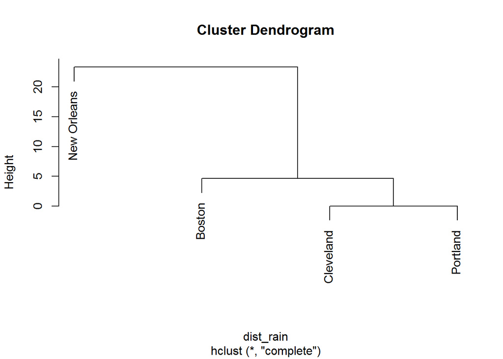

```r
# Create hc
hc <- hclust(dist_rain)

# Plot hc
plot(hc, labels = rain$city)
```

### Make a distance matrix and dendrogram from a TDM

Now that you understand the steps in making a dendrogram, you can apply them to text. But first, you have to limit the number of words in your TDM using removeSparseTerms() from tm. Why would you want to adjust the sparsity of the TDM/DTM?

TDMs and DTMs are sparse, meaning they contain mostly zeros. Remember that 1000 tweets can become a TDM with over 3000 terms! You won’t be able to easily interpret a dendrogram that is so cluttered, especially if you are working on more text.

```r
tweets <- read.csv("./data/coffee.csv", stringsAsFactors = FALSE)
coffee_tweets <- tweets$text
coffee_source <- VectorSource(coffee_tweets)
coffee_corpus <- VCorpus(coffee_source)
tweet_corp <- coffee_corpus
clean_corpus <- function(corpus){
  corpus <- tm_map(corpus, stripWhitespace)
  corpus <- tm_map(corpus, removePunctuation)
  corpus <- tm_map(corpus, content_transformer(tolower))
  corpus <- tm_map(corpus, removeWords, c(stopwords("en"), "coffee", "mug"))
  return(corpus)
}
clean_corp <- clean_corpus(tweet_corp)

# Create a TDM from clean_corp: coffee_tdm
coffee_tdm <- TermDocumentMatrix(clean_corp)

tweets_tdm <- coffee_tdm
# Print the dimensions of tweets_tdm
dim(tweets_tdm)
```

```
## [1] 3075 1000
```

```r
# Create tdm1
tdm1 <- removeSparseTerms(tweets_tdm, sparse = 0.95)

# Create tdm2
tdm2 <- removeSparseTerms(tweets_tdm, sparse = 0.975)


# Print tdm1
tdm1
```

```
## <<TermDocumentMatrix (terms: 6, documents: 1000)>>
## Non-/sparse entries: 416/5584
## Sparsity           : 93%
## Maximal term length: 7
## Weighting          : term frequency (tf)
```

```r
# Print tdm2
tdm2
```

```
## <<TermDocumentMatrix (terms: 40, documents: 1000)>>
## Non-/sparse entries: 1634/38366
## Sparsity           : 96%
## Maximal term length: 13
## Weighting          : term frequency (tf)
```

### Put it all together: a text based dendrogram

Its time to put your skills to work to make your first text-based dendrogram. Remember, dendrograms reduce information to help you make sense of the data. This is much like how an average tells you something, but not everything, about a population. Both can be misleading. With text, there are often a lot of nonsensical clusters, but some valuable clusters may also appear.

A peculiarity of TDM and DTM objects is that you have to convert them first to matrices (with as.matrix()), then to data frames (with as.data.frame()), before using them with the dist() function.

For the chardonnay tweets, you may have been surprised to see the soul music legend Marvin Gaye appear in the word cloud. Let’s see if the dendrogram picks up the same.

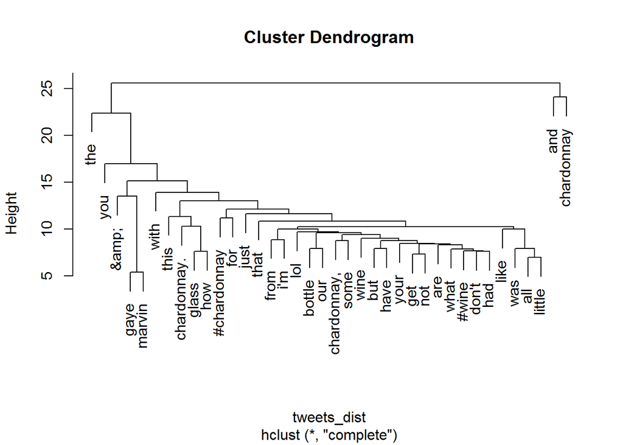

```r
# Create tweets_tdm2
tweets <- read.csv("./data/chardonnay_tweets.csv", stringsAsFactors = FALSE)

chardonnay_tweets <- tweets$text

clean_corpus <- function(corpus){
  corpus <- tm_map(corpus, removePunctuation)
  corpus <- tm_map(corpus, stripWhitespace)
  corpus <- tm_map(corpus, removeNumbers)
  corpus <- tm_map(corpus, content_transformer(tolower))
  corpus <- tm_map(corpus, removeWords, c(stopwords("en"), "amp", "glass", "chardonnay"))
  return(corpus)
}

tweet_source <- VectorSource(chardonnay_tweets)

text_corp <- VCorpus(tweet_source)

clean_corp <- clean_corpus(text_corp)

tweets_tdm <- TermDocumentMatrix(text_corp)

tweets_tdm2 <- removeSparseTerms(tweets_tdm, sparse = 0.975)

# Create tdm_m
tdm_m <- as.matrix(tweets_tdm2)

# Create tdm_df
tdm_df <- as.data.frame(tdm_m)

# Create tweets_dist
tweets_dist <- dist(tdm_df)

# Create hc
hc <- hclust(tweets_dist)

# Plot the dendrogram
plot(hc)
```

### Dendrogram aesthetics

So you made a dendrogram…but its not as eye catching as you had hoped!

The dendextend package can help your audience by coloring branches and outlining clusters. dendextend is designed to operate on dendrogram objects, so you’ll have to change the hierarchical cluster from hclust using as.dendrogram().

A good way to review the terms in your dendrogram is with the labels() function. It will print all terms of the dendrogram. To highlight specific branches, use branches_attr_by_labels(). First, pass in the dendrogram object, then a vector of terms as in c(“data”, “camp”). Lastly add a color such as “blue”.

After you make your plot, you can call out clusters with rect.dendrogram(). This adds rectangles for each cluster. The first argument to rect.dendrogram() is the dendrogram, followed by the number of clusters (k). You can also pass a border argument specifying what color you want the rectangles to be (e.g. “green”).

```r
# Load dendextend
library(dendextend)
```

```r
# Create hc
hc <- hclust(tweets_dist)

# Create hcd
hcd <- as.dendrogram(hc)

# Print the labels in hcd
labels(hcd)
```

```
##  [1] "the"         "you"         "&amp;"       "gaye"        "marvin"
##  [6] "with"        "this"        "chardonnay." "glass"       "how"
## [11] "#chardonnay" "for"         "just"        "that"        "from"
## [16] "i'm"         "lol"         "bottle"      "our"         "chardonnay,"
## [21] "some"        "wine"        "but"         "have"        "your"
## [26] "get"         "not"         "are"         "what"        "#wine"
## [31] "don't"       "had"         "like"        "was"         "all"
## [36] "little"      "and"         "chardonnay"
```

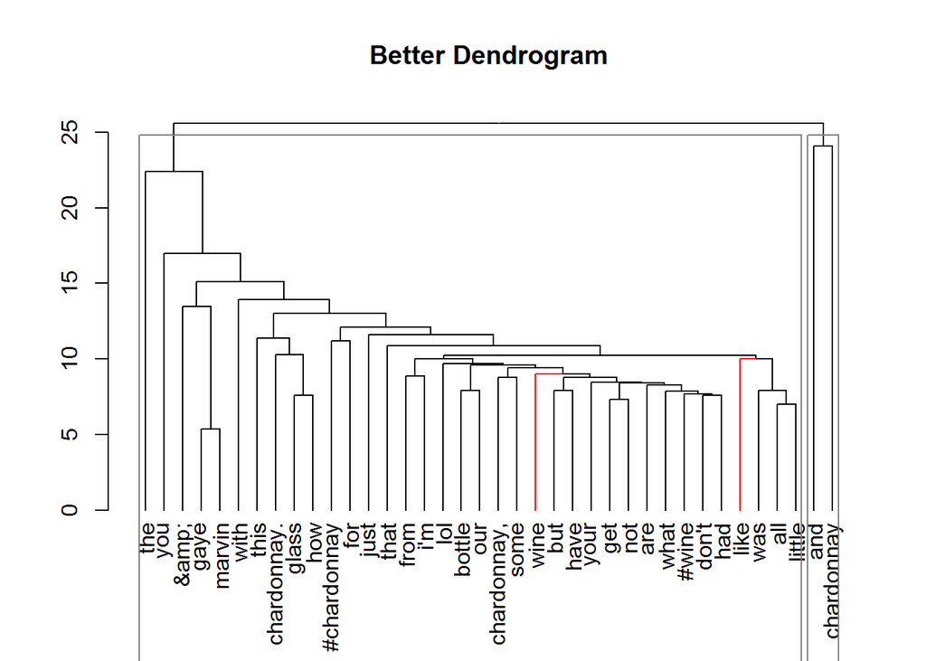

```r
# Change the branch color to red for "marvin" and "gaye"
hcd <- branches_attr_by_labels(hcd, c("wine", "like"), "red")

# Plot hcd
plot(hcd, main = "Better Dendrogram")

# Add cluster rectangles
plot(hcd, main = "Better Dendrogram")
rect.dendrogram(hcd, k = 2, border = "grey50")
```

### Using word association

Another way to think about word relationships is with the findAssocs() function in the tm package. For any given word, findAssocs() calculates its correlation with every other word in a TDM or DTM. Scores range from 0 to 1. A score of 1 means that two words always appear together, while a score of 0 means that they never appear together.

To use findAssocs() pass in a TDM or DTM, the search term, and a minimum correlation. The function will return a list of all other terms that meet or exceed the minimum threshold.

findAssocs(tdm, “word”, 0.25) Minimum correlation values are often relatively low because of word diversity. Don’t be surprised if 0.10 demonstrates a strong pairwise term association.

The coffee tweets have been cleaned and organized into tweets_tdm for the exercise. You will search for a term association, and manipulate the results with list_vect2df() from qdap and then create a plot with the ggplot2 code in the example script.

```r
# Create associations

tweets <- read.csv("./data/coffee_tweets.csv", stringsAsFactors = FALSE)

coffee_tweets <- tweets$text

clean_corpus <- function(corpus){
  corpus <- tm_map(corpus, removePunctuation)
  corpus <- tm_map(corpus, stripWhitespace)
  corpus <- tm_map(corpus, removeNumbers)
  corpus <- tm_map(corpus, content_transformer(tolower))
  corpus <- tm_map(corpus, removeWords, c(stopwords("en"), "amp", "cup", "coffee"))
  return(corpus)
}

tweet_source <- VectorSource(coffee_tweets)

text_corp <- VCorpus(tweet_source)

clean_corp <- clean_corpus(text_corp)

tweets_tdm <- TermDocumentMatrix(text_corp)

tweets_tdm2 <- removeSparseTerms(tweets_tdm, sparse = 0.975)

library(tm)
library(qdap)
library(ggplot2)
library(ggthemes)
associations <- findAssocs(tweets_tdm, "venti", 0.2)

# View the venti associations
associations
```

```
## $venti
##       #wtf     breve,        cuz    drizzle     entire     mocha,
##       0.58       0.58       0.58       0.58       0.58       0.58
##      pumps      extra     forget       now,       okay      hyper
##       0.58       0.47       0.41       0.41       0.41       0.33
##    vanilla     asleep     always       fall        get       from
##       0.33       0.29       0.26       0.26       0.25       0.24
## #starbucks        i'd  starbucks      white
##       0.23       0.23       0.23       0.23
```

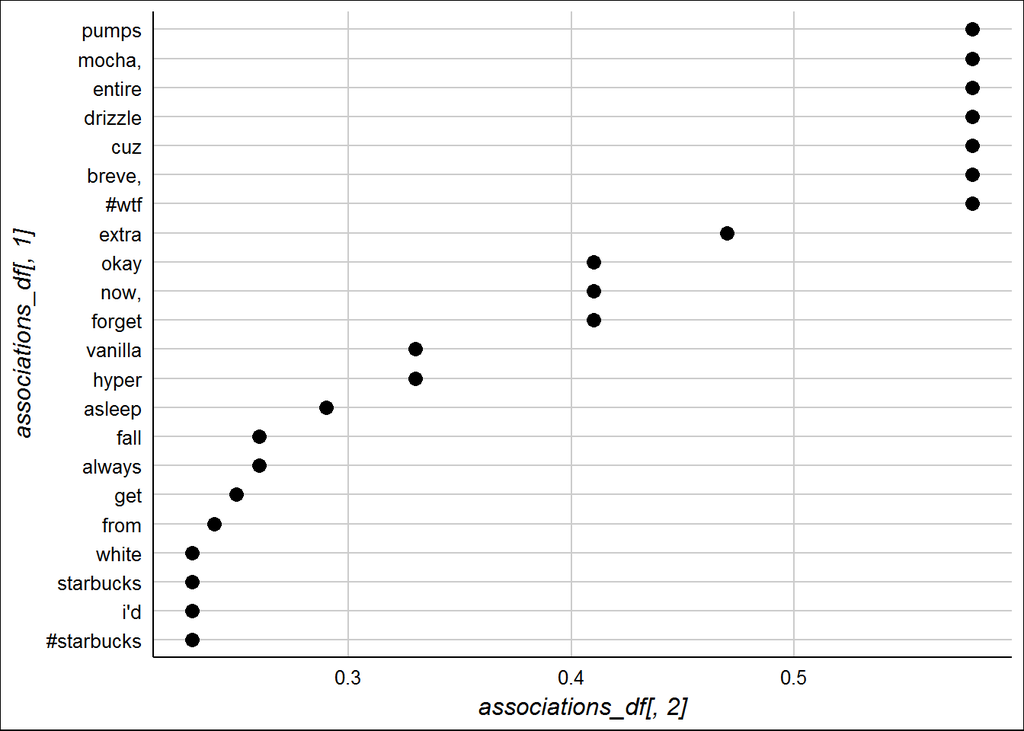

```r
# Create associations_df
associations_df <- as.data.frame(list_vect2df(associations)[, 2:3])

# Plot the associations_df values (don't change this)
ggplot(associations_df, aes(y = associations_df[, 1])) +
  geom_point(aes(x = associations_df[, 2]),
             data = associations_df, size = 3) +
  theme_gdocs()
```

### Changing n-grams

Increasing the number of n-grams will increase the terms in the TDM and DTM

So far, we have only made TDMs and DTMs using single words. The default is to make them with unigrams, but you can also focus on tokens containing two or more words. This can help extract useful phrases which lead to some additional insights or provide improved predictive attributes for a machine learning algorithm.

The function below uses the RWeka package to create trigram (three word) tokens: min and max are both set to 3.

tokenizer <- function(x) NGramTokenizer(x, Weka_control(min = 3, max = 3)) Then the customized tokenizer() function can be passed into the TermDocumentMatrix or DocumentTermMatrix functions as an additional parameter:

tdm <- TermDocumentMatrix( corpus, control = list(tokenize = tokenizer) )

```r
library(tm)
library(RWeka)
tweets <- read.csv("./data/chardonnay_tweets.csv", stringsAsFactors = FALSE)

chardonnay_tweets <- tweets$text

clean_corpus <- function(corpus){
  corpus <- tm_map(corpus, removePunctuation)
  corpus <- tm_map(corpus, stripWhitespace)
  corpus <- tm_map(corpus, removeWords, c(stopwords("en"), "amp", "glass", "chardonnay", "http //t"))
  return(corpus)
}

tweet_source <- VectorSource(chardonnay_tweets)

text_corp <- VCorpus(tweet_source)

# Make tokenizer function
tokenizer <- function(x)
  NGramTokenizer(x, Weka_control(min = 2, max = 2))

# Create unigram_dtm
unigram_dtm <- DocumentTermMatrix(text_corp)

# Create bigram_dtm
bigram_dtm <- DocumentTermMatrix(text_corp, control = list(tokenize = tokenizer))

# Examine unigram_dtm
#unigram_dtm

# Examine bigram_dtm
#bigram_dtm
```

### How do bigrams affect word clouds?

Now that you have made a bigram DTM, you can examine it and remake a word cloud. The new tokenization method affects not only the matrices, but also any visuals or modeling based on the matrices.

Remember how “Marvin” and “Gaye” were separate and large terms in the chardonnay word cloud? Using bigram tokenization grabs all two word combinations. Observe what happens to the word cloud in this exercise.

```r
library(wordcloud)
# Create bigram_dtm_m
bigram_dtm_m <- as.matrix(bigram_dtm)

# Create freq
freq <- colSums(bigram_dtm_m)
head(bigram_dtm_m, 1)
```

[output not shown]

[output cut: 4403 more lines]

[output not shown]

```r
# Create bi_words
bi_words <- names(freq)

# Examine part of bi_words
bi_words[2577:2587]
```

```
##  [1] "co/oalk9eib9o #wine"        "co/orjytkirj5 #wine"
##  [3] "co/pmolps4sny http"         "co/rmv84wgp3u #wine"
##  [5] "co/rznbptei1u on"           "co/s2upbd9o0g i"
##  [7] "co/sym5aceedg #wantone"     "co/ucsyvgev93 #winetourism"
##  [9] "co/uxhtbhvulw #wine"        "co/va5yfiovxn how"
## [11] "co/vperbmgtjn #video"
```

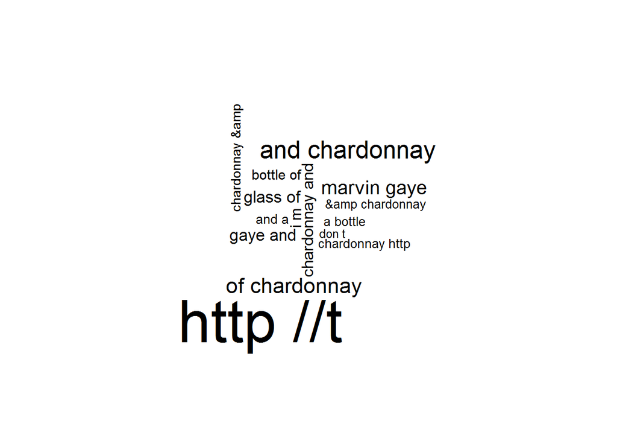

```r
# Plot a wordcloud
wordcloud(bi_words, freq, max.words = 15)
```

### Changing frequency weights

So far you have used term frequency to make the DocumentTermMatrix or TermDocumentMatrix. There are other term weights that can be helpful. The most popular weight is TfIdf, which stands for term frequency-inverse document frequency.

The TfIdf score increases by term occurrence but is penalized by the frequency of appearance among all documents.

From a common sense perspective, if a term appears often it must be important. This attribute is represented by term frequency (i.e. Tf), which is normalized by the length of the document. However, if the term appears in all documents, it is not likely to be insightful. This is captured in the inverse document frequency (i.e. Idf).

The wiki page on TfIdf contains the mathematical explanation behind the score, but the exercise will demonstrate the practical difference.

```r
tweets <- read.csv("./data/coffee_tweets.csv", stringsAsFactors = FALSE)

coffee_tweets <- tweets$text

clean_corpus <- function(corpus){
  corpus <- tm_map(corpus, removePunctuation)
  corpus <- tm_map(corpus, stripWhitespace)
  corpus <- tm_map(corpus, removeNumbers)
  corpus <- tm_map(corpus, content_transformer(tolower))
  corpus <- tm_map(corpus, removeWords, c(stopwords("en"), "amp", "cup"))
  return(corpus)
}

tweet_source <- VectorSource(coffee_tweets)

text_corp <- VCorpus(tweet_source)

text_corp <- clean_corpus(text_corp)

# Create tf_tdm
tf_tdm <- TermDocumentMatrix(text_corp)

# Create tfidf_tdm
tfidf_tdm <- TermDocumentMatrix(text_corp, control = list(weighting = weightTfIdf))

# Create tf_tdm_m
tf_tdm_m <- as.matrix(tf_tdm)

# Create tfidf_tdm_m
tfidf_tdm_m <- as.matrix(tfidf_tdm)

# Examine part of tf_tdm_m
tf_tdm_m[508:509, 5:10]
```

```
##             Docs
## Terms        5 6 7 8 9 10
##   coffeholic 0 0 0 0 0  0
##   cohorts    0 0 0 0 0  0
```

```r
# Examine part of tfidf_tdm_m
tfidf_tdm_m[508:509, 5:10]
```

```
##             Docs
## Terms        5 6 7 8 9 10
##   coffeholic 0 0 0 0 0  0
##   cohorts    0 0 0 0 0  0
```

### Capturing metadata in tm

100xp Depending on what you are trying to accomplish, you may want to keep metadata about the document when you create a TDM or DTM. This metadata can be incorporated into the corpus fairly easily by creating a readerControl list and applying it to a DataframeSource when calling VCorpus().

You will need to know the column names of the data frame containing the metadata to be captured. The names() function is helpful for this.

To capture the text column of the coffee tweets text along with a metadata column of unique numbers called num you would use the code below.

custom_reader <- readTabular( mapping = list(content = “text”, id = “num”) ) text_corpus <- VCorpus( DataframeSource(tweets), readerControl = list(reader = custom_reader) )

```r
# Add author to custom reading list
custom_reader <- readTabular(mapping = list(content = "text",
                                            id = "num",
                                            author = "screenName",
                                            date = "created"
                                            ))

# Make corpus with custom reading
text_corpus <- VCorpus(DataframeSource(tweets),
readerControl = list(reader = custom_reader))

function(corpus){
  corpus <- tm_map(corpus, content_transformer(tolower))
  corpus <- tm_map(corpus, removeWords, custom.stopwords)
  corpus <- tm_map(corpus, removePunctuation)
  corpus <- tm_map(corpus, stripWhitespace)
  corpus <- tm_map(corpus, removeNumbers)
  return(corpus)
}
```

```
## function(corpus){
##   corpus <- tm_map(corpus, content_transformer(tolower))
##   corpus <- tm_map(corpus, removeWords, custom.stopwords)
##   corpus <- tm_map(corpus, removePunctuation)
##   corpus <- tm_map(corpus, stripWhitespace)
##   corpus <- tm_map(corpus, removeNumbers)
##   return(corpus)
## }
```

```r
# Clean corpus
text_corpus <- clean_corpus(text_corpus)

# Print data
text_corpus[[1]][1]
```

```
## $content
## [1] "ayyytylerb    true drink lots  coffee"
```

```r
# Print metadata
text_corpus[[1]][2]
```

```
## $meta
##   id      : 1
##   author  : thejennagibson
##   date    : 8/9/2013 2:43
##   language: en
```

### Final text mining project - Steps 1 (Problem) and 2 (Find text to mine)

1. Problem definition
2. Unorganized state - identify text to mine

```r
goog <- read.csv("./data/google_reviews.csv")
goog$url <- as.character(goog$url)
goog$pros <- as.character(goog$pros)
goog$cons <- as.character(goog$cons)

amzn <- read.csv("./data/amazon_reviews.csv")
amzn$url <- as.character(amzn$url)
amzn$pros <- as.character(amzn$pros)
amzn$cons <- as.character(amzn$cons)

# Print the structure of amzn
str(amzn)
```

```
## 'data.frame':    500 obs. of  4 variables:
##  $ pg_num: int  50 50 50 50 50 50 50 50 50 50 ...
##  $ url   : chr  "https://www.glassdoor.com/Reviews/Amazon-com-Reviews-E6036_P50.htm" "https://www.glassdoor.com/Reviews/Amazon-com-Reviews-E6036_P50.htm" "https://www.glassdoor.com/Reviews/Amazon-com-Reviews-E6036_P50.htm" "https://www.glassdoor.com/Reviews/Amazon-com-Reviews-E6036_P50.htm" ...
##  $ pros  : chr  "You're surrounded by smart people and the projects are interesting, if a little daunting." "Brand name is great. Have yet to meet somebody who is unfamiliar with Amazon. Hours weren't as bad as I had previously heard. B"| __truncated__ "Good money.Interaction with some great mind…
##  $ cons  : chr  "Internal tools proliferation has created a mess for trying to get to basic information. Most people are required to learn/under"| __truncated__ "not the most stimulating work. Good brand name to work for but the work itself is mundane as it can get. As a financial analyst"| __tru…
```

```r
# Create amzn_pros
amzn_pros <- amzn$pros

# Create amzn_cons
amzn_cons <- amzn$cons

# Print the structure of goog
str(goog)
```

```
## 'data.frame':    501 obs. of  4 variables:
##  $ pg_num: int  1 1 1 1 1 1 1 1 1 1 ...
##  $ url   : chr  "https://www.glassdoor.com/Reviews/Google-Reviews-E9079_P1.htm" "https://www.glassdoor.com/Reviews/Google-Reviews-E9079_P1.htm" "https://www.glassdoor.com/Reviews/Google-Reviews-E9079_P1.htm" "https://www.glassdoor.com/Reviews/Google-Reviews-E9079_P1.htm" ...
##  $ pros  : chr  "* If you're a software engineer, you're among the kings of the hill at Google. It's an engineer-driven company without a doubt "| __truncated__ "1) Food, food, food. 15+ cafes on main campus (MTV) alone. Mini-kitchens, snacks, drinks, free breakfast/lunch/dinner, all day,"| __tru…
##  $ cons  : chr  "* It *is* becoming larger, and with it comes growing pains: bureaucracy, slow to respond to market threats, bloated teams, cros"| __truncated__ "1) Work/life balance. What balance? All those perks and benefits are an illusion. They keep you at work and they help you to be"| __tru…
```

```r
# Create goog_pros
goog_pros <- goog$pros

# Create goog_cons
goog_cons <- goog$cons

#Create goog_all
goog_all <- goog
```

#### Step 3 - Text Organization

Now that you have selected the exact text sources, you are ready to clean them up. You’ll be using the two functions you just saw in the video: qdap_clean(), which applies a series of qdap functions to a text vector, and tm_clean(), which applies a series of tm functions to a corpus object. You can refer back to the video to remind yourself of how they work.

In order to keep things simple, the functions have been defined for you and are available in your workspace. It’s your job to apply them to amzn_pros and amzn_cons!

```r
library(qdap)
library(tm)
qdap_clean <- function(x){
  x <- replace_abbreviation(x)
  x <- replace_contraction(x)
  x <- replace_number(x)
  x <- replace_ordinal(x)
  x <- replace_ordinal(x)
  x <- replace_symbol(x)
  x <- tolower(x)
  return(x)
}

tm_clean <- function(corpus){
  corpus <- tm_map(corpus, removePunctuation)
  corpus <- tm_map(corpus, stripWhitespace)
  corpus <- tm_map(corpus, removeWords, c(stopwords("en"), "google", "amazon", "company"))
  return(corpus)
}
#Alter goog_all
goog_all <- goog_all[, 3:4]
goog_all <- qdap_clean(goog_all)

#Create goog_all_corp
all_goog_corpus <- VCorpus(VectorSource(goog_all))

#alter_goog_all with tm
all_goog_corpus <- tm_clean(all_goog_corpus)

# Alter amzn_pros
amzn_pros <- qdap_clean(amzn_pros)

# Alter amzn_cons
amzn_cons <- qdap_clean(amzn_cons)

# Create az_p_corp
az_p_corp <- VCorpus(VectorSource(amzn_pros))

# Create az_c_corp
az_c_corp <- VCorpus(VectorSource(amzn_cons))

# Create amzn_pros_corp
amzn_pros_corp <- tm_clean(az_p_corp)

# Create amzn_cons_corp
amzn_cons_corp <- tm_clean(az_c_corp)

# Apply qdap_clean to goog_pros
goog_pros <- qdap_clean(goog_pros)

# Apply qdap_clean to goog_cons
goog_cons <- qdap_clean(goog_cons)

# Create goog_p_corp
goog_p_corp <- VCorpus(VectorSource(goog_pros))

# Create goog_c_corp
goog_c_corp <- VCorpus(VectorSource(goog_cons))

# Create goog_pros_corp
goog_pros_corp <- tm_clean(goog_p_corp)

# Create goog_cons_corp
goog_cons_corp <- tm_clean(goog_c_corp)
```

### Steps 4 and 5 - Feature Extraction and Analysis

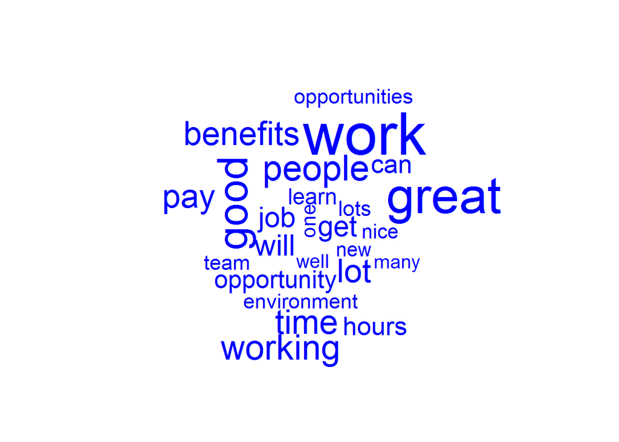

```r
options(expressions = 100000)

library(RWeka)
library(tm)
library(qdap)
library(wordcloud)
tokenizer <- function(x)
  NGramTokenizer(x, Weka_control(min = 2, max = 2))

# Create amzn_p_tdm
amzn_p_tdm <- TermDocumentMatrix(amzn_pros_corp, control = list(tokenize = tokenizer))

# Create amzn_p_tdm_m
amzn_p_tdm_m <- as.matrix(amzn_p_tdm)

# Create amzn_p_freq
amzn_p_freq <- rowSums(amzn_p_tdm_m)

# Plot a wordcloud using amzn_p_freq values
wordcloud(names(amzn_p_freq), max.words = 25, color = "blue")
```

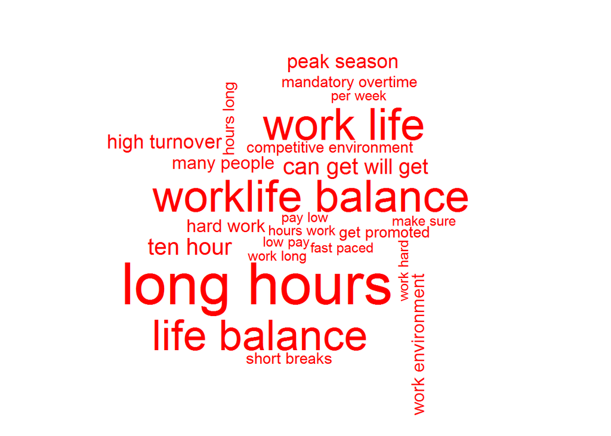

```r
# Create amzn_c_tdm
amzn_c_tdm <- TermDocumentMatrix(amzn_cons_corp, control = list(tokenize = tokenizer))

# Create amzn_c_tdm_m
amzn_c_tdm_m <- as.matrix(amzn_c_tdm)

# Create amzn_c_freq
amzn_c_freq <- rowSums(amzn_c_tdm_m)

# Plot a wordcloud of negative Amazon bigrams
wordcloud(names(amzn_c_freq), amzn_c_freq, max.words = 25, color = "red")
```

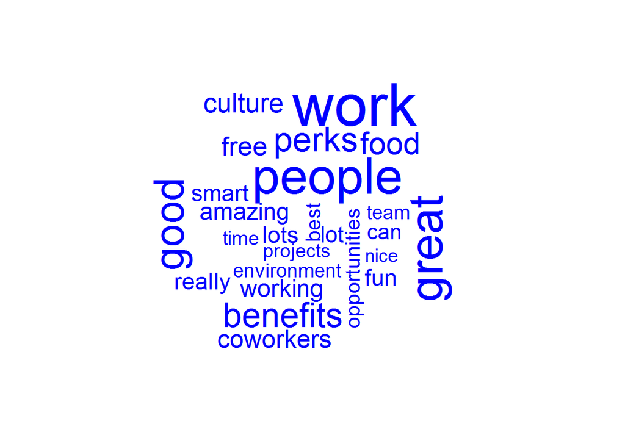

```r
#now for goog
# Create goog_p_tdm
goog_p_tdm <- TermDocumentMatrix(goog_pros_corp, control = list(tokenize = tokenizer))

# Create goog_p_tdm_m
goog_p_tdm_m <- as.matrix(goog_p_tdm)

# Create goog_p_freq
goog_p_freq <- rowSums(goog_p_tdm_m)

# Plot a wordcloud using goog_p_freq values
wordcloud(names(goog_p_freq), max.words = 25, color = "blue")
```

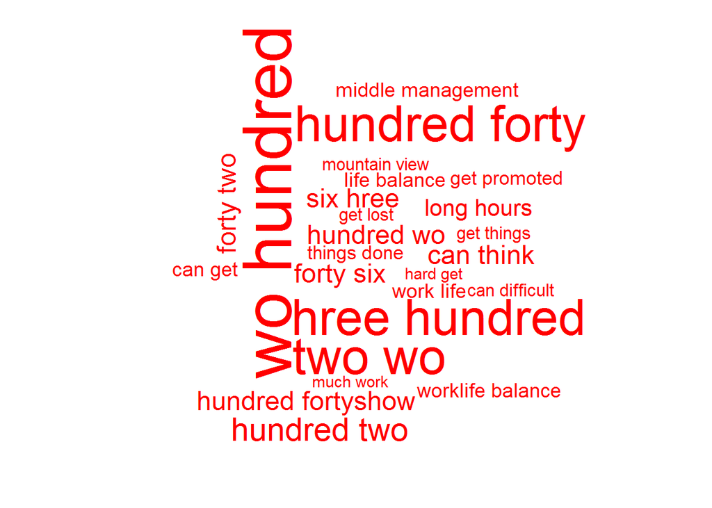

```r
# Create goog_c_tdm
goog_c_tdm <- TermDocumentMatrix(goog_cons_corp, control = list(tokenize = tokenizer))

# Create goog_c_tdm_m
goog_c_tdm_m <- as.matrix(goog_c_tdm)

# Create goog_c_freq
goog_c_freq <- rowSums(goog_c_tdm_m)

# Plot a wordcloud of negative google bigrams
wordcloud(names(goog_c_freq), goog_c_freq, max.words = 25, color = "red")
```

###amzn_cons dendrogram

It seems there is a strong indication of long working hours and poor work-life balance in the reviews. As a simple clustering technique, you decide to perform a hierarchical cluster and create a dendrogram to see how connected these phrases are.

```r
# Create amzn_c_tdm
amzn_c_tdm <- TermDocumentMatrix(amzn_cons_corp, control = list(tokenize = tokenizer))

# Print amzn_c_tdm to the console
amzn_c_tdm
```

```
## <<TermDocumentMatrix (terms: 4753, documents: 500)>>
## Non-/sparse entries: 5187/2371313
## Sparsity           : 100%
## Maximal term length: 31
## Weighting          : term frequency (tf)
```

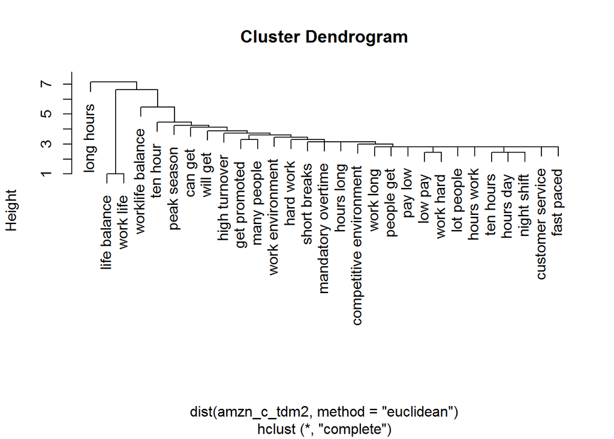

```r
# Create amzn_c_tdm2 by removing sparse terms
amzn_c_tdm2 <- removeSparseTerms(amzn_c_tdm, sparse = 0.993)

# Create hc as a cluster of distance values
hc <- hclust(dist(amzn_c_tdm2, method = "euclidean"), method = "complete")

# Produce a plot of hc
plot(hc)
```

### Word association

As expected, you see similar topics throughout the dendrogram. Switching back to positive comments, you decide to examine top phrases that appeared in the word clouds. You hope to find associated terms using the findAssocs()function from tm. You want to check for something surprising now that you have learned of long hours and a lack of work-life balance.

```r
# Create amzn_p_tdm
amzn_p_tdm <- TermDocumentMatrix(amzn_pros_corp, control = list(tokenize = tokenizer))

# Create amzn_p_m
amzn_p_m <- as.matrix(amzn_p_tdm)

# Create amzn_p_freq
amzn_p_freq <- rowSums(amzn_p_m)

# Create term_frequency
term_frequency <- sort(amzn_p_freq, decreasing = TRUE)

# Print the 5 most common terms
term_frequency[1:5]
```

```
##       good pay great benefits   smart people     place work     fast paced
##             25             24             20             17             16
```

```r
# Find associations with fast paced
findAssocs(x = amzn_p_tdm, terms = "fast paced", corlimit = 0.2)
```

```
## $`fast paced`
##        paced environment        environments ever               learn fast
##                     0.49                     0.35                     0.35
##           paced friendly               paced work               able excel
##                     0.35                     0.35                     0.25
##           activity ample              advance one                also well
##                     0.25                     0.25                     0.25
##              amount time        ample opportunity        assistance ninety
##                     0.25                     0.25                     0.25
##       benefits including           break computer            call activity
##                     0.25                     0.25                     0.25
##               can choose            catchy cheers            center things
##                     0.25                     0.25                     0.25
##       challenging expect       cheers opportunity           choose success
##                     0.25                     0.25                     0.25
##   combined encouragement competitive environments            computer room
##                     0.25                     0.25                     0.25
##              cool things          deliver results               dock makes
##                     0.25                     0.25                     0.25
##           driven deliver               easy learn        emphasis shipping
##                     0.25                     0.25                     0.25
## encouragement innovation     environment benefits       environment catchy
##                     0.25                     0.25                     0.25
##       environment center         environment fast         environment help
##                     0.25                     0.25                     0.25
##        environment smart               ever known           ever witnessed
##                     0.25                     0.25                     0.25
##        everchanging fast    everyones preferences            excel advance
##                     0.25                     0.25                     0.25
##       excel everchanging     exciting environment             expect learn
##                     0.25                     0.25                     0.25
##        experience noting           extremely fast             facility top
##                     0.25                     0.25                     0.25
##          fail successful           fantastic able               fired part
##                     0.25                     0.25                     0.25
##             five percent           freindly place      friendly atmosphere
##                     0.25                     0.25                     0.25
##      friendly management             full medical                get fired
##                     0.25                     0.25                     0.25
##             go extremely             great plenty           great teamwork
```

[output cut: 38 more lines]

```
##                     0.25                     0.25                     0.25
##              team driven         technology today         things happening
##                     0.25                     0.25                     0.25
##               things lot                time fast                  time go
##                     0.25                     0.25                     0.25
##                 top line       upfront experience              vision well
##                     0.25                     0.25                     0.25
##              volume call            well rewarded             well tuition
##                     0.25                     0.25                     0.25
##       witnessed combined                 work can                work cool
##                     0.25                     0.25                     0.25
##        work environments                work fast                 work job
##                     0.25                     0.25                     0.25
##          workers readily              yell leader
##                     0.25                     0.25
```

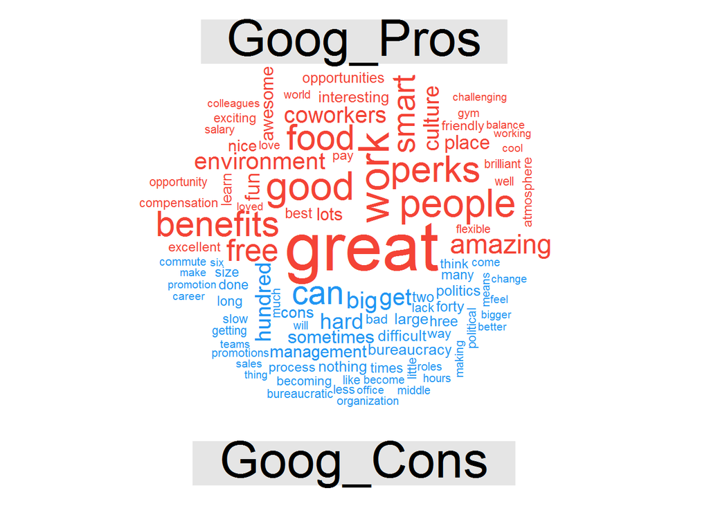

```r
# Create all_goog_corp
all_goog_corp <- tm_clean(all_goog_corpus)

# Create all_tdm
all_tdm <- TermDocumentMatrix(all_goog_corp)

# Name the columns of all_tdm
colnames(all_tdm) <- c("Goog_Pros", "Goog_Cons")

# Create all_m
all_m <- as.matrix(all_tdm)

# Build a comparison cloud
comparison.cloud(all_m, colors = c("#F44336", "#2196f3"), max.words = 100)
```

### Cage match! Amazon vs. Google pro reviews

In contrast, Google’s positive reviews mention “great food”, “perks”, “smart people”, and “fun culture”, among other things. Google’s negative reviews discuss “politics”, “getting big”, “bureaucracy”, and “middle management”.

You decide to make a pyramid plot lining up positive reviews for Amazon and Google so you can adequately see the differences between any shared birgrams.

```r
amzn_tweets <- read.csv("./data/amazon_reviews.csv", stringsAsFactors = FALSE)

goog_tweets <- read.csv("./data/google_reviews.csv", stringsAsFactors = FALSE)

amzn_pros <- amzn_tweets$pros

goog_pros <- goog_tweets$pros

#google had one more positive tweet, so I just removed the last one to make the data frame work
all_pros <- data.frame(Amazon_Pros = amzn_pros, Google_Pros = goog_pros[-501])

all_source <- VectorSource(all_pros)

all_corp <- VCorpus(all_source)

tm_clean <- function(corpus){
  corpus <- tm_map(corpus, removePunctuation)
  corpus <- tm_map(corpus, stripWhitespace)
  corpus <- tm_map(corpus, removeWords, c(stopwords("en"), "google", "amazon", "company"))
  return(corpus)
}

all_corpus <- VCorpus(VectorSource(all_corp))

all_corpus <- tm_clean(all_corpus)

all_tdm <- TermDocumentMatrix(all_corpus, control = list(tokenize = tokenizer))

all_tdm_m <- as.matrix(all_tdm)

#all_tdm_m <- read.csv("./data/all_tdm_source.csv", stringsAsFactors = FALSE, header = TRUE, skip = 1)

head(all_tdm_m)
```

```
##              Docs
## Terms         1 2
##   1 countless 0 1
##   1 employees 1 0
##   1 food      0 1
##   1 good      0 1
##   1 open      0 1
##   1 place     0 2
```

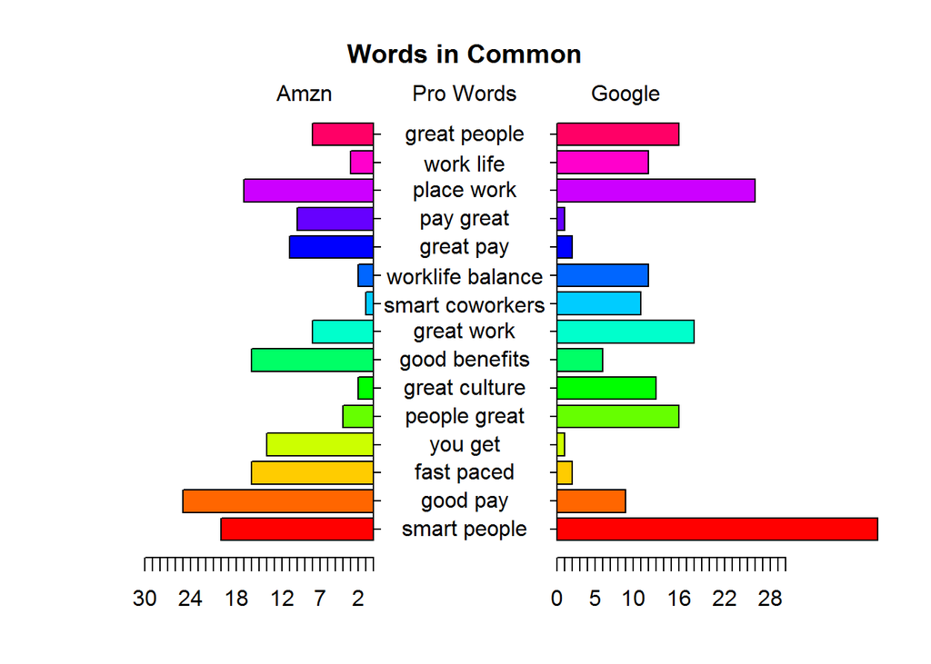

```
## [1] 5.1 4.1 4.1 2.1
```

```r
# Create common_words
common_words <- subset(all_tdm_m, all_tdm_m[, 1] > 0 & all_tdm_m[, 2] > 0)

# Create difference
difference <- abs(common_words[, 1] - common_words[, 2])

# Add difference to common_words
common_words <- cbind(common_words, difference)

# Order the data frame from most differences to least
common_words <- common_words[order(common_words[, 3], decreasing = TRUE), ]

# Create top15_df
top15_df <- data.frame(x = common_words[1:15, 1], y = common_words[1:15, 2], labels = rownames(common_words[1:15, ]))

# Create the pyramid plot
library(plotrix)
pyramid.plot(top15_df$x, top15_df$y,
             labels = top15_df$labels, gap = 12,
             top.labels = c("Amzn", "Pro Words", "Google"),
             main = "Words in Common", unit = NULL)
```

### Cage match, part 2! Negative reviews

Interestingly, some Amazon employees discussed “work-life balance” as a positive. In both organizations, people mentioned “culture” and “smart people”, so there are some similar positive aspects between the two companies.

You now decide to turn your attention to negative reviews and make the same visual. This time, all_tdm_m contains the negative reviews, or cons, from both organizations.

```r
amzn_tweets <- read.csv("./data/amazon_reviews.csv", stringsAsFactors = FALSE)

goog_tweets <- read.csv("./data/google_reviews.csv", stringsAsFactors = FALSE)

amzn_cons <- amzn_tweets$cons

goog_cons <- goog_tweets$cons

#google had one more negative tweet, so I just removed the last one to make the data frame work
all_cons <- data.frame(Amazon_Cons = amzn_cons, Google_Cons = goog_cons[-501])

all_source <- VectorSource(all_cons)

all_corp <- VCorpus(all_source)

tm_clean <- function(corpus){
  corpus <- tm_map(corpus, removePunctuation)
  corpus <- tm_map(corpus, stripWhitespace)
  corpus <- tm_map(corpus, removeWords, c(stopwords("en"), "google", "amazon", "company"))
  return(corpus)
}

all_corpus <- VCorpus(VectorSource(all_corp))

all_corpus <- tm_clean(all_corpus)

all_tdm <- TermDocumentMatrix(all_corpus, control = list(tokenize = tokenizer))

all_tdm_m <- as.matrix(all_tdm)

head(all_tdm_m)
```

```
##                  Docs
## Terms             1 2
##   0 benefits      1 0
##   1 2             0 1
##   1 hour          1 0
##   1 inexperienced 0 1
##   1 limited       0 1
##   1 not           0 1
```

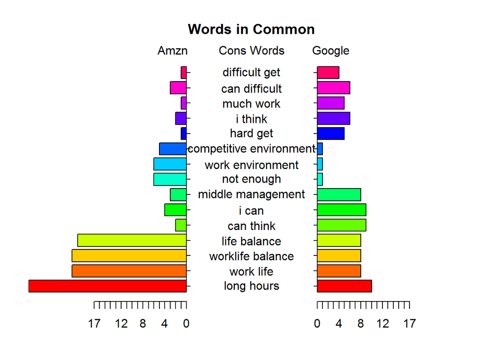

```
## [1] 5.1 4.1 4.1 2.1
```

```r
# Create common_words
common_words <- subset(all_tdm_m, all_tdm_m[, 1] > 0 & all_tdm_m[, 2] > 0)

# Create difference
difference <- abs(common_words[, 1] - common_words[, 2])

# Add difference to common_words
common_words <- cbind(common_words, difference)

# Order the data frame from most differences to least
common_words <- common_words[order(common_words[, 3], decreasing = TRUE), ]

# Create top15_df
top15_df <- data.frame(x = common_words[1:15, 1], y = common_words[1:15, 2], labels = rownames(common_words[1:15, ]))

# Create the pyramid plot
library(plotrix)
pyramid.plot(top15_df$x, top15_df$y,
             labels = top15_df$labels, gap = 12,
             top.labels = c("Amzn", "Cons Words", "Google"),
             main = "Words in Common", unit = NULL)
```

### Step 6 - Reach a conclusion